# data-load_figures-1-to-4

Alexander Hogrebe

Current version 30 May, 2022

# Load libraries and functions

To generate the input files for this script, use script Comet-Mokapot-hits-input_IsobaricQuant.Rmd, or download all pre-generated input files from the associated PRIDE repository of this publication and copy them into the “data” folder.

```r
#load libraries
library(data.table)
library(foreach)
library(ggplot2)
library(viridis)
library(cowplot)


#define functions and themes
#combine two strings
string_combine <- function(string_list, link = "_", string_priority=c("first", "last")) {
  if(!is.list(string_list)) stop("'string_list' must be a list of vectors")
  string_priority <- match.arg(string_priority)

  if(string_priority=="first") {
    apply(expand.grid(rev(string_list))[, length(string_list):1], 1, paste, collapse=link)
  } else {
    apply(expand.grid(string_list), 1, paste, collapse=link)
  }
}

#load function to recreate old Comet peptide sequence output
peptide_gsub <- function(string, input = c("CO", "FP", "MQ")){
  input <- match.arg(input)
  if(!is.character(string)) stop("'input' needs to be a character vector")

  if(input=="CO"){
    string <- gsub("n[42.0106]", "(ac)", string, fixed = T)
    string <- gsub("[15.9949]", "(ox)", string, fixed = T)
  }

  if(input=="FP"){
    string <- gsub("n[305]", "", string, fixed=T)
    string <- gsub("[305]", "", string, fixed=T)
    string <- gsub("n[43]", "(ac)", string, fixed=T)
    string <- gsub("[160]", "(ca)", string, fixed=T)
    string <- gsub("[147]", "(ox)", string, fixed=T)
  }

  if(input=="MQ"){
    string <- gsub("(Oxidation (M))", "(ox)", string, fixed=T)
    string <- gsub("(Acetyl (Protein N-term))", "(ac)", string, fixed=T)
  }

  return(string)
}

#dcast fun.aggregate unique function
dcast_unique <- function(x) paste0(unique(x), collapse = ";")

#dcast fun.aggregate unique function
dcast_unique_sort <- function(x) paste0(sort(unique(x)), collapse = ";")

#function to report 0, 1, infinite, NA and NAN
check_nonval <- function(x) {
  print(paste("Total of", length(x), "contains", length(which(x==0)), "0s,",
              length(which(x==1)), "1s,", length(which(is.infinite(x))), "inf,",
              length(which(is.na(x))), "NA", length(which(is.nan(x))), "NAN and",
              length(which(x!=0 & x !=1 & !is.infinite(x) & !is.na(x) & !is.nan(x) & is.numeric(x))), "valid"))
}

#y-axis percentage
theme_yaxis_percentage <- scale_y_continuous(labels = scales::percent_format())

#tilt x-axis labels
theme_tilt_xaxis <- function(angle, set_vjust = F) {
  if(set_vjust){
    theme(axis.text.x = element_text(angle = angle, hjust = 1, vjust = 0.5))
  } else {
    theme(axis.text.x = element_text(angle = angle, hjust = 1))
  }
}


#define sample conditions
sample_dil_val <- c("empty_1", string_combine(list( c("1to20", "1to10", "1to4", "1to2", "1to1"), as.character(1:3L) )))
sample_val <- string_combine(list( c("RTS", "SPS", "MS2"), as.character(1L:3L), sample_dil_val ))

cond_val <- unique(gsub("^(.*_.*)_.*_.$", "\\1", sample_val))
cond_col <- viridis(9)
names(cond_col) <- cond_val

cond_met_val_old <- c("MS2", "SPS", "RTS")
cond_met_val <- c("MS2", "SPS-MS3", "RTS-MS3")
cond_met_col <- viridis(3)
names(cond_met_col) <- cond_met_val

cond_qua_val <- c("IQ", "FP", "MQ")
cond_qua_col <- viridis(3)
names(cond_qua_col) <- cond_qua_val

cond_org_val <- c("YEAST", "HUMAN;YEAST", "HUMAN", "OTHER")
cond_org_col <- viridis(6)[c(1, 2, 3, 6)]
names(cond_org_col) <- cond_org_val

sample_dil_col <- viridis(16)
names(sample_dil_col) <- sample_dil_val

cond_dil_val <- unique(gsub("^(.*)_.$", "\\1", sample_dil_val))
cond_dil_col <- viridis(6)
names(cond_dil_col) <- cond_dil_val

aa_val <- c("K", "R", "A", "P")
aa_col <- viridis(4)
names(aa_col) <- aa_val
```

# Read Comet, Mokapot and IsobaricQuant results

Load Comet and Mokapot hits files, then filter Comet with Mokapot q-value and merge with IsobaricQuant output files. Next load IQ generated csv files into R from generated sub-folder structure.

```r
file_list <- c("a18182_MS2_1", "a18183_SPS_1", "a18184_RTS_1",
               "a18185_MS2_2", "a18186_SPS_2", "a18187_RTS_2",
               "a18188_MS2_3", "a18189_SPS_3", "a18190_RTS_3")

data <- foreach(file = file_list, .combine = rbind) %do% {

  #load Percolator output
  data <- fread(paste0("data/", file, ".mokapot.psms.txt"))

  #create tag and merge two datasets
  data[, raw := (file)]
  setkey(data, ScanNr)

  #filter comet output based on q-value
  data <- data[`mokapot q-value`<=0.01]
  print(paste0(file, " yields ", data[, .N], " entries of q-value < 0.01"))

  return(data)
}
```

```
## [1] "a18182_MS2_1 yields 14390 entries of q-value < 0.01"
## [1] "a18183_SPS_1 yields 9318 entries of q-value < 0.01"
## [1] "a18184_RTS_1 yields 14179 entries of q-value < 0.01"
## [1] "a18185_MS2_2 yields 14056 entries of q-value < 0.01"
## [1] "a18186_SPS_2 yields 8961 entries of q-value < 0.01"
## [1] "a18187_RTS_2 yields 14126 entries of q-value < 0.01"
## [1] "a18188_MS2_3 yields 14123 entries of q-value < 0.01"
## [1] "a18189_SPS_3 yields 9017 entries of q-value < 0.01"
## [1] "a18190_RTS_3 yields 15018 entries of q-value < 0.01"
```

```r
data[, peptideID := 1:.N, by = c("raw")]
```

## Load isolab.csv files

isolab.csv files generated by IsobaricQuant contain reporter ion intensities per ms2/3 scan group.

```r
#load isolab.csv files from folder structure
files <- list.files(path = "data", recursive = T, full.names = T, pattern = "^isolab\\.csv$")
#read in files via for loop
data_IQ <- foreach(file = files, .combine = rbind)  %do% {
  temp <- data.table(raw = gsub("^.*data/([^/]*)_output/isolab\\.csv$", "\\1", file), fread(file))
  return(temp)
}

#delete TMT zero and rename samples
data_IQ <- data_IQ[labelName !="zero"]
old_lab <- c("126", string_combine(list(as.character(127:133), c("N", "C")), link = ""), "134N")
data_IQ[, sample := factor(labelName, levels = old_lab, labels = sample_dil_val)]

#check intensity for validity, and set 0 to NA
data_IQ[, check_nonval(maxIntensity)]
```

```
## [1] "Total of 1262352 contains 46153 0s, 0 1s, 0 inf, 0 NA 0 NAN and 1216199 valid"
```

```
## [1] "Total of 1262352 contains 46153 0s, 0 1s, 0 inf, 0 NA 0 NAN and 1216199 valid"
```

```r
data_IQ[maxIntensity==0 | maxIntensity==1, maxIntensity := NA]
#log10 transform intensity,
data_IQ[, maxIntensity := log10(maxIntensity)]
```

### Map peptides and isolab

```r
data_CO <- merge(data, data_IQ, by = c("raw", "peptideID"), all.x=T, all.y=F)

#kick out RTS IDs without quants
data_CO <- data_CO[!is.na(labelName)]

data_CO[raw=="a18184_RTS_1", sample := paste0("RTS_1_", sample)]
data_CO[raw=="a18187_RTS_2", sample := paste0("RTS_2_", sample)]
data_CO[raw=="a18190_RTS_3", sample := paste0("RTS_3_", sample)]
data_CO[raw=="a18182_MS2_1", sample := paste0("MS2_1_", sample)]
data_CO[raw=="a18185_MS2_2", sample := paste0("MS2_2_", sample)]
data_CO[raw=="a18188_MS2_3", sample := paste0("MS2_3_", sample)]
data_CO[raw=="a18183_SPS_1", sample := paste0("SPS_1_", sample)]
data_CO[raw=="a18186_SPS_2", sample := paste0("SPS_2_", sample)]
data_CO[raw=="a18189_SPS_3", sample := paste0("SPS_3_", sample)]

#parse columns and create conditions
data_CO[, sample := factor(sample, levels = sample_val)]
data_CO[, condition := factor(gsub("^(.*_.*)_.*_.$", "\\1", sample), levels = cond_val)]
data_CO[, cond_met := factor(gsub("^(.*)_.*_.*_.$", "\\1", sample), levels = cond_met_val_old, labels = cond_met_val)]
data_CO[, cond_dil := factor(gsub("^.*_._(.*_.)$", "\\1", sample), levels = sample_dil_val)]
data_CO[, replicate := factor(gsub("^.*_(.)$", "\\1", sample), levels = 1L:3L)]
data_CO[, rep_met := factor(gsub("^.*_(.)_.*_.$", "\\1", sample), levels = 1L:3L)]
data_CO[, raw_file := factor(raw, levels = unique(sort(raw)), labels = 1:length(unique(raw)))]
data_CO[, reverse := F]
data_CO[, gene := character()]
data_CO[, protein_split := sapply(Proteins, function(x) strsplit(x, "\t", fixed=T) )]
data_CO[, proteins := lapply(protein_split, function(x) gsub("^[^\\|]*\\|([^\\|]*)\\|[^\\|]*$", "\\1", x) )]
data_CO[, organism := sapply(protein_split, function(x) dcast_unique_sort(gsub("^[^\\|]*\\|[^\\|]*\\|[^\\|]*_(.*)$", "\\1", x)) )]
data_CO[, protein := sapply(proteins, function(x) x[1] )]
data_CO[, charge := as.integer(gsub("^.*_.*_.*_.*_(.*)_.*$", "\\1", SpecId))]
data_CO[, peptide_mod := peptide_gsub(gsub("^..(.*)..$", "\\1", Peptide), "CO")]
data_CO[, peptide_seq := gsub("(\\(..\\))", "", peptide_mod)]
data_CO[, peptide_z := paste0(peptide_mod, "_", charge)]
data_CO[, mz_ratio := (ExpMass+charge*1.0073)/charge]
data_CO[, intensity := maxIntensity]
data_CO[, intensity_MS1 := numeric()]
data_CO[, score := `mokapot score`]
data_CO[, qscore := numeric()]
data_CO[, scan_ms2 := ScanNr]
data_CO[, scan_ms3 := firstScan]
data_CO <- data_CO[, .(sample, condition, cond_met, cond_dil, replicate, rep_met, raw_file, reverse,
                 gene, protein, proteins, organism, peptide_mod, peptide_seq, peptide_z,
                 charge, mz_ratio, intensity, intensity_MS1, score, qscore, scan_ms2, scan_ms3)]

data_CO <- copy(data_CO)
setkey(data_CO, sample, peptide_z)
```

## Load isopep_extra files

isopep_extra.csv files generated by IsobaricQuant contain QC scores.

```r
#create IQ wide table
data_IQw <- cbind(dcast(data_IQ, raw + peptideID ~ sample, value.var = "maxIntensity"),
                  dcast(data_IQ, raw + peptideID ~ ., value.var = c("firstScan", "lastScan", "maxIntensityScan"),
                        fun.aggregate = dcast_unique)[, -c(1,2)])

#load isopep_extra.csv files from folder structure
files <- list.files(path = "data", recursive = T, full.names = T, pattern = "^isopep_extra\\.csv$")
#read in files via for loop
data_IQ_ex <- foreach(file = files, .combine = rbind)  %do% {
  temp <- data.table(raw = gsub("^.*data/([^/]*)_output/isopep_extra\\.csv$", "\\1", file), fread(file))
  return(temp)
}
#names(data_IQ)
data_IQ_ex[, quantID := NULL]
```

### Map peptides and isopep_extra

```r
#merge IQ isolab onto CO
data_COw <- merge(data, data_IQw, by = c("raw", "peptideID"), all.x=T, all.y=F)

#kick out RTS IDs without quants
data_COw <- data_COw[!is.na(maxIntensityScan)]

#parse columns and create conditions
data_COw[, sample := factor(gsub("^.*_(.*_.*)$", "\\1", raw), levels = cond_val)]
data_COw[, condition := factor(gsub("^(.*)_.$", "\\1", sample), levels = cond_met_val_old, labels = cond_met_val)]
data_COw[, replicate := factor(gsub("^.*_(.)$", "\\1", sample), levels = 1L:3L)]
data_COw[, raw_file := factor(raw, levels = unique(sort(raw)), labels = 1:length(unique(raw)))]
data_COw[, reverse := F]
data_COw[, gene := character()]
data_COw[, protein_split := sapply(Proteins, function(x) strsplit(x, "\t", fixed=T) )]
data_COw[, proteins := lapply(protein_split, function(x) gsub("^[^\\|]*\\|([^\\|]*)\\|[^\\|]*$", "\\1", x) )]
data_COw[, organism := sapply(protein_split, function(x) dcast_unique_sort(gsub("^[^\\|]*\\|[^\\|]*\\|[^\\|]*_(.*)$", "\\1", x)) )]
data_COw[, protein := sapply(proteins, function(x) x[1] )]
data_COw[, charge := as.integer(gsub("^.*_.*_.*_.*_(.*)_.*$", "\\1", SpecId))]
data_COw[, peptide_mod := peptide_gsub(gsub("^..(.*)..$", "\\1", Peptide), "CO")]
data_COw[, peptide_seq := gsub("(\\(..\\))", "", peptide_mod)]
data_COw[, peptide_z := paste0(peptide_mod, "_", charge)]
data_COw[, mz_ratio := (ExpMass+charge*1.0073)/charge]
data_COw[, intensity_MS1 := numeric()]
data_COw[, score := `mokapot score`]
data_COw[, qscore := numeric()]
data_COw[, scan_ms2 := ScanNr]
data_COw[, scan_ms3 := firstScan]
data_COw <- data_COw[, .SD, .SDcols = c("raw", "peptideID", "sample", "condition", "replicate", "raw_file", "reverse",
                                        "gene", "protein", "proteins", "organism", "peptide_mod", "peptide_seq", "peptide_z",
                                        "charge", "mz_ratio", sample_dil_val, "intensity_MS1",
                                        "score", "qscore", "scan_ms2", "scan_ms3")]
setkey(data_COw, sample, peptide_z)

#merge IQ isopep_extra onto CO wide
data_COw <- merge(data_COw, data_IQ_ex, by = c("raw", "peptideID"), all.x=T, all.y=F)
data_COw[, c("raw", "peptideID") := NULL]

data_COw <- copy(data_COw)
setkey(data_COw, sample, peptide_z)
```

# QC parameters

IsobaricQuant generates a variety of QC scores that can be used to assess and filter ratio compression within data sets.

## Calculate ratios

The HYpro16 benchmark consists of 16 TMTpro channels of mixed yeast and human peptides. Human peptides were labeled 1:1 for all channels. Yeast peptides were empty in channel 126, and then diluted 20:10:4:2:1 in triplicates each from 127N to 134N. Throughout this study, the 20:1 ratio is mostly used for quantitative comparisons.

```r
#calculate ratios
data_COw[, ratio_20_1 := 10^(`1to1_1`-`1to20_1`)]
data_COw[, ratio_20_2 := 10^(`1to1_2`-`1to20_2`)]
data_COw[, ratio_20_3 := 10^(`1to1_3`-`1to20_3`)]
data_COw[, ratio_20_m := apply(.SD, 1, function(x) mean(x, na.rm=T) ), .SDcols = c("ratio_20_1", "ratio_20_2", "ratio_20_3")]

data_COw[, ratio_10_1 := 10^(`1to1_1`-`1to10_1`)]
data_COw[, ratio_10_2 := 10^(`1to1_2`-`1to10_2`)]
data_COw[, ratio_10_3 := 10^(`1to1_3`-`1to10_3`)]
data_COw[, ratio_10_m := apply(.SD, 1, function(x) mean(x, na.rm=T) ), .SDcols = c("ratio_10_1", "ratio_10_2", "ratio_10_3")]

data_COw[, ratio_4_1 := 10^(`1to1_1`-`1to4_1`)]
data_COw[, ratio_4_2 := 10^(`1to1_2`-`1to4_2`)]
data_COw[, ratio_4_3 := 10^(`1to1_3`-`1to4_3`)]
data_COw[, ratio_4_m := apply(.SD, 1, function(x) mean(x, na.rm=T) ), .SDcols = c("ratio_4_1", "ratio_4_2", "ratio_4_3")]

data_COw[, ratio_2_1 := 10^(`1to1_1`-`1to2_1`)]
data_COw[, ratio_2_2 := 10^(`1to1_2`-`1to2_2`)]
data_COw[, ratio_2_3 := 10^(`1to1_3`-`1to2_3`)]
data_COw[, ratio_2_m := apply(.SD, 1, function(x) mean(x, na.rm=T) ), .SDcols = c("ratio_2_1", "ratio_2_2", "ratio_2_3")]

#calculate empty channel percentage of full
data_COw[!is.na(empty_1), ratio_empty_max := apply(.SD, 1, function(x) 10^(x[1]-max(x, na.rm=T)) ), .SDcols = sample_dil_val]

#calculate ratio counts
count_cols <- c("ratio_20_m", "ratio_10_m", "ratio_4_m", "ratio_2_m", "ratio_empty_max")
count_names <- c("ratio 1:20", "ratio 1:10", "ratio 1:4", "ratio 1:2", "ratio empty max")
data_COw[, ratio_any_valid := apply(.SD, 1, function(x) any(!is.na(x)) ), .SDcols = count_cols]
```

## QC overview pdfs

This code block creates pdf output files that correlate TMT ratios with each individual QC parameter, separated into the MS acquisition methods. The output files are not included in this report, as they are fairly large and contain one page per MS acquisition method and QC score.

```r
#define y intercepts
yic <- data.table(type = factor(count_names, levels=count_names), intercept = (c(20, 10, 4, 2, 0)))


#define plotting function
QC_par_plot <- function(data, par_list, par_title, file_name) {
  temp <- copy(data)
  max_y <- temp[,  max(ratio, na.rm=T)]

  plot_list <- foreach(QC_par = QC_par_list, .combine = c) %do% {
    p_1 <- ggplot(temp, aes_string(x=QC_par[[1]], y="ratio")) +
      geom_point(alpha=0.1) + geom_smooth(method="lm") + geom_hline(data = yic, mapping = aes(yintercept = intercept), linetype = "dashed") +
      facet_wrap(type ~ ., scales = "free_y", nrow = 1) + theme_minimal_grid() +
      ggtitle(paste0(par_title[1], QC_par[[1]], " ", QC_par[[2]], par_title[2]))

    temp[, bin := factor(QC_par[[3]][1], levels = QC_par[[3]])]
    temp[get(QC_par[[1]])>=QC_par[[4]][1], bin := QC_par[[3]][2]]
    temp[get(QC_par[[1]])>=QC_par[[4]][2], bin := QC_par[[3]][3]]

    lab <- temp[!is.na(get(QC_par[[1]])) & !is.na(ratio), .(N = .N, y = max(ratio, na.rm=T)), keyby = c("type", "bin")]

    p_2 <- ggplot(temp, aes(x=bin, y=ratio)) + geom_hline(data = yic, mapping = aes(yintercept = intercept), linetype = "dashed") +
      geom_boxplot() + geom_text(data=lab, aes(x=bin, y=y, label=N), nudge_x = -0.25) +
      facet_wrap(type ~ ., scales = "free_y", nrow = 1) + theme_minimal_grid()

    p <- plot_grid(p_1, p_2, ncol = 1)
    return(list(p))
  }

  #multi page pdf from plot_list
  pdf(paste0("figures/", file_name), width = 20, height = 10)
  for (i in 1:length(plot_list)) {
    print(plot_list[[i]])
  }
  dev.off()

}


# === MS1-based QC parameters ===
QC_par_list <- list( list( "ms1PrecSIgnal", "(= int MS1 prec in MS1 window)", c("<0.75", "0.75<x<1", "=1"), c(0.75, 1) ) )
QC_cols <- sapply(QC_par_list, function(x) x[[1]] )

##MS1-based (MS2 only)
QC_data <- data_COw[organism=="YEAST" & ratio_any_valid==T & condition %in% c("MS2")]
QC_data <- melt(QC_data, id.vars = QC_cols, measure.vars = count_cols, variable.name = "type", value.name = "ratio")
QC_data[, type := factor(type, levels = count_cols, labels = count_names)]

QC_par_plot(QC_data, QC_par_list, c("MS1 ", " (MS2 only)"), "MS1-parameters_MS2-only.pdf")


##MS1-based (MS3 only)
QC_data <- data_COw[organism=="YEAST" & ratio_any_valid==T & condition %in% cond_met_val[c(2,3)]]
QC_data <- melt(QC_data, id.vars = QC_cols, measure.vars = count_cols, variable.name = "type", value.name = "ratio")
QC_data[, type := factor(type, levels = count_cols, labels = count_names)]

QC_par_plot(QC_data, QC_par_list, c("MS1 ", " (MS3 only)"), "MS1-parameters_MS3-only.pdf")



# === MS2-based QC parameters ===
QC_par_list <- list( list( "msnTotalSignal_log10", "= int rep", c("<1e6", "1e6<x<1e7", ">1e7"), c(6, 7) ),
                     list( "peptideIntensityScore", "= int b/y in total MS2", c("<0.25", "0.25<x<0.5", ">0.5"), c(0.25, 0.5) ),
                     list( "peptideTopXIntensityScore", "= int topX b/y in topX", c("<0.8", "0.8<x<1", "=1"), c(0.8, 1) ),
                     list( "peptideTopXIntensityFromTotalScore", "= int topX b/y in MS2", c("<0.15", "0.15<x<0.3", ">0.3"), c(0.15, 0.3) ),
                     list( "topXIntensityFromTotalScore", "= int topX in MS2", c("<0.2", "0.2<x<0.4", ">0.4"), c(0.2, 0.4) ),
                     list( "topXPeptidePeaksRatio", "= num b/y in topX", c("<0.25", "0.25<x<0.75", ">0.75"), c(0.25, 0.75) ),
                     list( "topPeakIntensityTopXScore", "= int top peak in topX", c("<0.2", "0.2<x<0.4", ">0.4"), c(0.2, 0.4) ),
                     list( "topPeakIntensityScore", "= int top peak in MS2", c("<0.05", "0.05<x<0.1", ">0.1"), c(0.05, 0.1) ),
                     list( "topPeakFromPeptide", "= is top peak b/y", c("no", "no2", "yes"), c(0.5, 1) ),
                     list( "topPeakFromNL", "= is top peak NL", c("no", "no2", "yes"), c(0.5, 1) ) )
QC_cols <- sapply(QC_par_list, function(x) x[[1]] )

#MS2-based (MS2 only)
#good ones: topXIntensityFromTotalScore, msnTotalSignal_log10
QC_data <- data_COw[organism=="YEAST" & ratio_any_valid==T & condition %in% c("MS2")]
QC_data[, msnTotalSignal_log10 := log10(msnTotalSignal)]
QC_data <- melt(QC_data, id.vars = QC_cols, measure.vars = count_cols, variable.name = "type", value.name = "ratio")
QC_data[, type := factor(type, levels = count_cols, labels = count_names)]

QC_par_plot(QC_data, QC_par_list, c("MS2 ", " (MS2 only)"), "MS2-parameters_MS2-only.pdf")

#MS2-based (SPS only)
#good ones: peptideIntensityScore, topXIntensityFromTotalScore
QC_data <- data_COw[organism=="YEAST" & ratio_any_valid==T & condition %in% cond_met_val[c(2)]]
QC_data[, msnTotalSignal_log10 := log10(msnTotalSignal)]
QC_data <- melt(QC_data, id.vars = QC_cols, measure.vars = count_cols, variable.name = "type", value.name = "ratio")
QC_data[, type := factor(type, levels = count_cols, labels = count_names)]

QC_par_plot(QC_data, QC_par_list, c("MS2 ", " (SPS only)"), "MS2-parameters_SPS-only.pdf")

#MS2-based (RTS only)
#good ones: peptideIntensityScore, topXIntensityFromTotalScore
QC_data <- data_COw[organism=="YEAST" & ratio_any_valid==T & condition %in% cond_met_val[c(3)]]
QC_data[, msnTotalSignal_log10 := log10(msnTotalSignal)]
QC_data <- melt(QC_data, id.vars = QC_cols, measure.vars = count_cols, variable.name = "type", value.name = "ratio")
QC_data[, type := factor(type, levels = count_cols, labels = count_names)]

QC_par_plot(QC_data, QC_par_list, c("MS2 ", " (RTS only)"), "MS2-parameters_RTS-only.pdf")




# === MS3-based QC parameters ===
QC_par_list <- list( list( "precRepIntRatio", "= int b/y in SPS window", c("<0.5", "0.5<x<0.75", ">0.75"), c(0.5, 0.75) ),
                     list( "precTPIntRatio", "= int SPS in SPS window", c("<0.8", "0.8<x<0.9", ">0.9"), c(0.8, 0.9) ),
                     list( "precTPNumRatio", "= num SPS in SPS window", c("<0.3", "0.3<x<0.4", ">0.4"), c(0.3, 0.4) ) )
QC_cols <- sapply(QC_par_list, function(x) x[[1]] )

#MS2-based (SPS only)
QC_data <- data_COw[organism=="YEAST" & ratio_any_valid==T & condition %in% cond_met_val[c(2)]]
QC_data[is.infinite(precRepIntRatio), precRepIntRatio := NA]
QC_data <- melt(QC_data, id.vars = QC_cols, measure.vars = count_cols, variable.name = "type", value.name = "ratio")
QC_data[, type := factor(type, levels = count_cols, labels = count_names)]

QC_par_plot(QC_data, QC_par_list, c("MS3 ", " (SPS only)"), "MS3-parameters_SPS-only.pdf")

#MS2-based (RTS only)
QC_data <- data_COw[organism=="YEAST" & ratio_any_valid==T & condition %in% cond_met_val[c(3)]]
QC_data[is.infinite(precRepIntRatio), precRepIntRatio := NA]
QC_data <- melt(QC_data, id.vars = QC_cols, measure.vars = count_cols, variable.name = "type", value.name = "ratio")
QC_data[, type := factor(type, levels = count_cols, labels = count_names)]

QC_par_plot(QC_data, QC_par_list, c("MS3 ", " (RTS only)"), "MS3-parameters_RTS-only.pdf")
```

## QC score scaling

```r
# heatmap of all correlations and slopes ?!?
count_cols <- c("ratio_20_m", "ratio_10_m", "ratio_4_m", "ratio_2_m", "ratio_empty_max")
count_names <- c("ratio 1:20", "ratio 1:10", "ratio 1:4", "ratio 1:2", "ratio empty max")
QC_cols <-
  c("ms1PrecSIgnal", "msnTotalSignal_log10", "peptideIntensityScore", "peptideTopXIntensityScore", "peptideTopXIntensityFromTotalScore",
    "topXIntensityFromTotalScore", "topXPeptidePeaksRatio", "topPeakIntensityTopXScore", "topPeakIntensityScore",
    "topPeakFromPeptide", "topPeakFromNL", "precRepIntRatio", "precTPIntRatio", "precTPNumRatio")
#log10 transform msnTotalSignal
data_COw[, msnTotalSignal_log10 := log10(msnTotalSignal)]
#melt reporter ion columns into tidy format
QC_data <- melt(data_COw[organism=="YEAST" & ratio_any_valid==T],
                id.vars = c("sample", "condition", QC_cols), measure.vars = count_cols, variable.name = "type", value.name = "ratio")
QC_data[, type := factor(type, levels = count_cols, labels = count_names)]
#melt QC columns into tidy format
QC_data[, topPeakFromPeptide := as.numeric(topPeakFromPeptide)]
QC_data[, topPeakFromNL := as.numeric(topPeakFromNL)]
QC_data <- melt(QC_data, id.vars = c("sample", "condition", "type", "ratio"), measure.vars = QC_cols,
                variable.name = "QC_par", value.name = "score")
#remove inf scores and MS2-files from MS3-QC-scores
QC_data <- QC_data[!is.infinite(score)]
QC_data <- QC_data[!is.nan(score)]
QC_data <- QC_data[!(QC_par %in% c("precRepIntRatio", "precTPIntRatio", "precTPNumRatio") & condition %in% "MS2")]

#scale scores from 0 to 1 within QC_par
QC_data[, score_scaled := (score-min(score))/max(score-min(score)), by = c("sample", "type", "QC_par")]

p_scores_MS2 <- ggplot(QC_data[type=="ratio 1:20" & condition=="MS2"], aes(x=score)) +
  geom_density() + facet_wrap(vars(QC_par), scales="free") + theme_minimal_grid() + ggtitle("MS2 scores") +
  theme(strip.text.x = element_text(size = 8))
p_scores_SPS <- ggplot(QC_data[type=="ratio 1:20" & condition=="SPS-MS3"], aes(x=score)) +
  geom_density() + facet_wrap(vars(QC_par), scales="free") + theme_minimal_grid() + ggtitle("SPS-MS3 scores") +
  theme(strip.text.x = element_text(size = 8))
p_scores_RTS <- ggplot(QC_data[type=="ratio 1:20" & condition=="RTS-MS3"], aes(x=score)) +
  geom_density() + facet_wrap(vars(QC_par), scales="free") + theme_minimal_grid() + ggtitle("RTS-MS3 scores") +
  theme(strip.text.x = element_text(size = 8))

p_scores_scaled_MS2 <- ggplot(QC_data[type=="ratio 1:20" & condition=="MS2"], aes(x=score_scaled)) +
  geom_density() + facet_wrap(vars(QC_par), scales="free") + theme_minimal_grid() + ggtitle("MS2 scores scaled") +
  theme(strip.text.x = element_text(size = 8))
p_scores_scaled_SPS <- ggplot(QC_data[type=="ratio 1:20" & condition=="SPS-MS3"], aes(x=score_scaled)) +
  geom_density() + facet_wrap(vars(QC_par), scales="free") + theme_minimal_grid() + ggtitle("SPS-MS3 scores scaled") +
  theme(strip.text.x = element_text(size = 8))
p_scores_scaled_RTS <- ggplot(QC_data[type=="ratio 1:20" & condition=="RTS-MS3"], aes(x=score_scaled)) +
  geom_density() + facet_wrap(vars(QC_par), scales="free") + theme_minimal_grid() + ggtitle("RTS-MS3 scores scaled") +
  theme(strip.text.x = element_text(size = 8))
```

### Figure S5

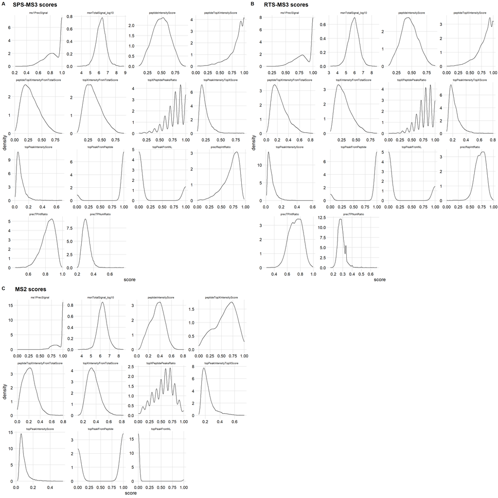

```r
#score distributions, raw and scaled
plot_grid(p_scores_SPS, p_scores_RTS, p_scores_MS2, labels = "AUTO", ncol = 2, rel_heights = c(4,3))
```

```r
ggsave2("figures/fig_S5.pdf", width = 20, height = 12.5)
```

## QC slope heatmap

This code block creates slope correlation heatmaps (Fig 4a).

```r
#calculate lm slope and cor
QC_data_lm <- QC_data[!is.na(ratio) & !is.na(score_scaled), .(slope = coefficients(summary(lm(ratio ~ score_scaled, .SD)))[2, "Estimate"],
                          R_squared = cor(ratio, score_scaled)^2),
                      keyby = c("condition", "QC_par", "type")]
QC_data_lm[, lab_R_squared := paste0("R^2 = ", round(R_squared, 2))]
QC_data_lm[type!="ratio empty max", col_R_squared := ifelse(slope<2, "grey", "black")]
QC_data_lm[type=="ratio empty max", col_R_squared := ifelse(slope>-0.05, "grey", "black")]

#plots for supplementary figure
p_slope_r_all <- ggplot(QC_data_lm[type!="ratio empty max"], aes(x=type, y=QC_par, fill=slope, label=lab_R_squared)) +
  geom_tile() + geom_text(aes(color=col_R_squared)) +
  scale_fill_viridis(option = "E") + scale_color_identity("slope") + xlab("") + ylab("") +
  facet_grid(rows = vars(condition)) + theme_minimal_grid()

p_slope_r_empty <- ggplot(QC_data_lm[type=="ratio empty max"], aes(x=condition, y=QC_par, fill=-slope, label=lab_R_squared)) +
  geom_tile() + geom_text(aes(color=col_R_squared)) +
  scale_fill_viridis("negative\nslope", option = "E") + scale_color_identity() + xlab("") + ylab("") +
  theme_minimal_grid()


#facet with MS-level labeling
QC_par_list <- list( list( "ms1PrecSIgnal", "= intensity precursor in MS1 window", c("<0.75", "0.75<x<1", "=1"), c(0.75, 1) ),
                     list( "msnTotalSignal_log10", "= intensity reporters", c("<1e6", "1e6<x<1e7", ">1e7"), c(6, 7) ),
                     list( "peptideIntensityScore", "= intensity b/y in total MS2", c("<0.25", "0.25<x<0.5", ">0.5"), c(0.25, 0.5) ),
                     list( "peptideTopXIntensityScore", "= intensity topX b/y in topX", c("<0.8", "0.8<x<1", "=1"), c(0.8, 1) ),
                     list( "peptideTopXIntensityFromTotalScore", "= intensity topX b/y in MS2", c("<0.15", "0.15<x<0.3", ">0.3"), c(0.15, 0.3) ),
                     list( "topXIntensityFromTotalScore", "= intensity topX in MS2", c("<0.2", "0.2<x<0.4", ">0.4"), c(0.2, 0.4) ),
                     list( "topXPeptidePeaksRatio", "= number b/y in topX", c("<0.25", "0.25<x<0.75", ">0.75"), c(0.25, 0.75) ),
                     list( "topPeakIntensityTopXScore", "= intensity top peak in topX", c("<0.2", "0.2<x<0.4", ">0.4"), c(0.2, 0.4) ),
                     list( "topPeakIntensityScore", "= intensity top peak in MS2", c("<0.05", "0.05<x<0.1", ">0.1"), c(0.05, 0.1) ),
                     list( "topPeakFromPeptide", "= is top peak b/y?", c("no", "no2", "yes"), c(0.5, 1) ),
                     list( "topPeakFromNL", "= is top peak NL?", c("no", "no2", "yes"), c(0.5, 1) ),
                     list( "precRepIntRatio", "= intensity b/y in SPS windows", c("<0.5", "0.5<x<0.75", ">0.75"), c(0.5, 0.75) ),
                     list( "precTPIntRatio", "= intensity peaks in SPS windows", c("<0.8", "0.8<x<0.9", ">0.9"), c(0.8, 0.9) ),
                     list( "precTPNumRatio", "= number peaks in SPS windows", c("<0.3", "0.3<x<0.4", ">0.4"), c(0.3, 0.4) ) )

QC_data_lm[, QC_par_ext := factor(QC_par, levels = sapply(QC_par_list, function(x) x[1] )[14:1],
                                  labels = sapply(QC_par_list, function(x) paste0(x[1], "\n", x[2]) )[14:1])]
QC_data_lm[, QC_par_des := factor(QC_par, levels = sapply(QC_par_list, function(x) x[1] ),
                                  labels = sapply(QC_par_list, function(x) gsub("= ", "", x[2], fixed = T) ))]

#filter unhelpful scores
QC_data_lm <- QC_data_lm[!QC_par %in% c("topPeakIntensityTopXScore", "topPeakFromNL", "precTPNumRatio")]
QC_data_lm[, condition := factor(condition, levels = cond_met_val, labels = c("MS2", "SPS-\nMS3", "RTS-\nMS3"))]

p_point_slope <- ggplot(QC_data_lm[type=="ratio 1:20"], aes(x=condition, y=QC_par_ext, color=slope, size=R_squared)) +
  geom_point() + geom_hline(yintercept = c(2.5, 10.5), linetype = "dashed") + xlab("") + ylab("") +
  scale_color_viridis("slope", option = "E") + scale_size_continuous("R^2", range = c(0,10)) +
  theme_minimal_grid() + theme(legend.position = "bottom")
p_point_slope_legend <- get_legend(p_point_slope)
```

## QC to ratio correlations

This code block generates QC score to 20:1 yeast peptide ratio correlations (Fig 4b and 4c).

```r
#here: only use yeast peptides
data_COy <- data_COw[organism=="YEAST"]

# == QC score vs ratio correlation ==
#correlation and cutoff plots
data_COy_MS3 <- data_COy[ratio_any_valid==T & !is.na(peptideIntensityScore) & !is.na(ratio_20_m)]
p_ratio_cor_peptideIntensityScore <- ggplot(data_COy_MS3, aes(x=peptideIntensityScore, y=ratio_20_m)) +
  stat_density_2d(geom = "polygon", aes(fill = after_stat(level))) +
  geom_hline(yintercept = 20, linetype = "dashed") + xlim(0,1) +
  facet_grid(rows = vars(condition)) + scale_fill_viridis("density") + theme_minimal_grid() + ylab("peptide mean ratio 20:1")


data_COy_MS3 <- data_COy[ratio_any_valid==T & !is.na(peptideTopXIntensityFromTotalScore) & !is.na(ratio_20_m)]
p_ratio_cor_peptideTopXIntensityFromTotalScore <- ggplot(data_COy_MS3, aes(x=peptideTopXIntensityFromTotalScore, y=ratio_20_m)) +
  stat_density_2d(geom = "polygon", aes(fill = after_stat(level))) +
  geom_hline(yintercept = 20, linetype = "dashed") + xlim(0,1) +
  facet_grid(rows = vars(condition)) + scale_fill_viridis("density") + theme_minimal_grid() + ylab("peptide mean ratio 20:1")


data_COy_MS3 <- data_COy[ratio_any_valid==T & !is.na(msnTotalSignal_log10) & !is.na(ratio_20_m)]
p_ratio_cor_msnTotalSignal_log10 <- ggplot(data_COy_MS3, aes(x=msnTotalSignal_log10, y=ratio_20_m)) +
  stat_density_2d(geom = "polygon", aes(fill = after_stat(level))) +
  geom_hline(yintercept = 20, linetype = "dashed") + xlab("log 10 msnTotalSignal") +
  facet_grid(rows = vars(condition)) + scale_fill_viridis("density") + theme_minimal_grid() + ylab("peptide mean ratio 20:1")


data_COy_MS3 <- data_COy[ratio_any_valid==T & !is.na(ms1PrecSIgnal) & !is.na(ratio_20_m)]
#label number of ms1PrecSIgnal==1
data_COy_MS3[, ms1PrecSIgnal_eq1 := ms1PrecSIgnal==1]
count_1 <- data_COy_MS3[, .N, keyby = c("condition", "ms1PrecSIgnal_eq1")][, .(ms1_1 = paste0(round(N[2]/sum(N), 3)*100, "% excluded")),
                                                                           keyby = c("condition")]
p_ratio_cor_ms1PrecSIgnal <- ggplot(data_COy_MS3[ms1PrecSIgnal!=1], aes(x=ms1PrecSIgnal, y=ratio_20_m)) +
  stat_density_2d(geom = "polygon", aes(fill = after_stat(level))) + geom_hline(yintercept = 20, linetype = "dashed") +
  geom_text(data=count_1, aes(x=0, y=19, label=ms1_1), hjust=0, vjust=1) +
  xlab("ms1PrecSignal (excluding =1)") + xlim(0,1) + ylim(0,25) +
  facet_grid(cols = vars(condition)) + scale_fill_viridis("density") + theme_minimal_grid() + ylab("peptide mean ratio 20:1")


count_1_shown <- data_COy_MS3[, .N, keyby = c("condition", "ms1PrecSIgnal_eq1")][, .(ms1_1 = paste0(round(N[2]/sum(N), 3)*100, "% shown")), keyby = c("condition")]
p_ratio_density_ms1PrecSIgnal_1 <- ggplot(data_COy_MS3[ms1PrecSIgnal==1], aes(x=ratio_20_m)) +
  geom_density() + geom_vline(xintercept = 20, linetype = "dashed") + xlab("peptide mean ratio 20:1\n(only showing ms1PrecSignal = 1)") +
  geom_text(data=count_1_shown, aes(x=35, y=0.14, label=ms1_1), hjust=0.5, vjust=1) + ylab("density") +
  facet_grid(rows = vars(condition)) + theme_minimal_grid()
```

## Peptide mean ratio

This code block generates yeast peptide mean ratios plots (Fig 4d).

```r
#here: only use yeast peptides
data_COy <- data_COw[organism=="YEAST"]


# == peptide mean ratio, separated by methods ==
#peptideIntensityScore
QC_pep_ratio <-
  rbind(data_COy[!is.na(ratio_20_m), .(ratio = ratio_20_m, type = c(">0")),
                 keyby = c("sample", "condition", "protein")],
        data_COy[!is.na(ratio_20_m) & peptideIntensityScore>0.25, .(ratio = ratio_20_m, type = c(">0.25")),
                 keyby = c("sample", "condition", "protein")],
        data_COy[!is.na(ratio_20_m) & peptideIntensityScore>0.5, .(ratio = ratio_20_m, type = c(">0.5")),
                 keyby = c("sample", "condition", "protein")])
QC_pep_ratio[, type := factor(type, levels = c(">0", ">0.25", ">0.5"))]
lab <- QC_pep_ratio[!is.na(ratio), .(N = .N, y = quantile(ratio, na.rm=T)["75%"]), keyby = c("condition", "type")]

p_pep_ratio_peptideIntensityScore <- ggplot(QC_pep_ratio, aes(x=condition, y=ratio, fill=type)) +
  geom_boxplot(outlier.alpha = 0.2, color = "grey", lwd=0.5, fatten=1) +
  geom_text(data=lab, aes(x=condition, y=y+c(1.5, 3.5, 4), label=N), position = position_dodge(0.75), size = 3) +
  scale_fill_viridis_d("peptideIntensityScore", option = "B") + xlab("") + ylab("peptide mean ratio 20:1") +
  theme_minimal_hgrid() + theme(legend.position = "top") + guides(fill = guide_legend(title.position="top"))



#peptideTopXIntensityFromTotalScore
QC_pep_ratio <-
  rbind(data_COy[!is.na(ratio_20_m), .(ratio = ratio_20_m, type = c(">0")),
                 keyby = c("sample", "condition", "protein")],
        data_COy[!is.na(ratio_20_m) & peptideTopXIntensityFromTotalScore>0.15, .(ratio = ratio_20_m, type = c(">0.15")),
                 keyby = c("sample", "condition", "protein")],
        data_COy[!is.na(ratio_20_m) & peptideTopXIntensityFromTotalScore>0.3, .(ratio = ratio_20_m, type = c(">0.3")),
                 keyby = c("sample", "condition", "protein")])
QC_pep_ratio[, type := factor(type, levels = c(">0", ">0.15", ">0.3"))]
lab <- QC_pep_ratio[!is.na(ratio), .(N = .N, y = quantile(ratio, na.rm=T)["75%"]), keyby = c("condition", "type")]

p_pep_ratio_peptideTopXIntensityFromTotalScore <- ggplot(QC_pep_ratio, aes(x=condition, y=ratio, fill=type)) +
  geom_boxplot(outlier.alpha = 0.2, color = "grey", lwd=0.5, fatten=1) +
  geom_text(data=lab, aes(x=condition, y=y+c(1.5, 3.5, 4), label=N), position = position_dodge(0.75), size = 3) +
  scale_fill_viridis_d("peptideTopXIntensityFromTotalScore", option = "B") + xlab("") + ylab("peptide mean ratio 20:1") +
  theme_minimal_hgrid() + theme(legend.position = "top") + guides(fill = guide_legend(title.position="top"))


#msnTotalSignal_log10
QC_pep_ratio <-
  rbind(data_COy[!is.na(ratio_20_m), .(ratio = ratio_20_m, type = c(">0")),
                 keyby = c("sample", "condition", "protein")],
        data_COy[!is.na(ratio_20_m) & msnTotalSignal_log10>6, .(ratio = ratio_20_m, type = c(">1e6")),
                 keyby = c("sample", "condition", "protein")],
        data_COy[!is.na(ratio_20_m) & msnTotalSignal_log10>7, .(ratio = ratio_20_m, type = c(">1e7")),
                 keyby = c("sample", "condition", "protein")])
QC_pep_ratio[, type := factor(type, levels = c(">0", ">1e6", ">1e7"))]
lab <- QC_pep_ratio[!is.na(ratio), .(N = .N, y = quantile(ratio, na.rm=T)["75%"]), keyby = c("condition", "type")]

p_pep_ratio_msnTotalSignal_log10 <- ggplot(QC_pep_ratio, aes(x=condition, y=ratio, fill=type)) +
  geom_boxplot(outlier.alpha = 0.2, color = "grey", lwd=0.5, fatten=1) +
  geom_text(data=lab, aes(x=condition, y=y+c(1.5, 2.5, 3), label=N), position = position_dodge(0.75), size = 3) +
  scale_fill_viridis_d("msnTotalSignal", option = "B") + xlab("") + ylab("peptide mean ratio 20:1") +
  theme_minimal_hgrid() + theme(legend.position = "top") + guides(fill = guide_legend(title.position="top"))
```

## Protein CV and median ratio (min 2 peptides)

This code block generates yeast protein median ratio plots, where filtering at all cutoffs retains at least 2 peptide observations per protein (Fig 4e and S6).

```r
#here: only use yeast peptides
data_COy <- data_COw[organism=="YEAST"]
data_COy[!is.na(ratio_20_m), n_pep := .N, by = c("sample", "protein")]

#1: calculate number of peptides per protein (number peptides above QC threshold, min 2)
#2: sort by protein & QC score
#3: calculate accuracy & CV per peptides indicated peptide column

# == msnTotalSignal_log10 ==
data_min2_msnT <- data_COy[n_pep>=2, .SD, keyby = c("sample", "protein", "msnTotalSignal")]

data_min2_msnT[, QC_thr1 := msnTotalSignal>1e6]
data_min2_msnT[, QC_thr2 := msnTotalSignal>1e7]
data_min2_msnT[, n_pep_QC1 := ifelse(length(which(QC_thr1))>=2, length(which(QC_thr1)), 2L), by = c("sample", "protein")]
data_min2_msnT[, n_pep_QC2 := ifelse(length(which(QC_thr2))>=2, length(which(QC_thr2)), 2L), by = c("sample", "protein")]
data_min2_msnT[, QC_pep1 := (n_pep[1]:1) %in% (n_pep_QC1[1]:1), by = c("sample", "protein")]
data_min2_msnT[, QC_pep2 := (n_pep[1]:1) %in% (n_pep_QC2[1]:1), by = c("sample", "protein")]
data_min2_msnT[, change := n_pep_QC2<n_pep]

prot_min2_msnT <- rbind(data_min2_msnT[, .(type = "all proteins", ratio = median(ratio_20_m), CV = sd(ratio_20_m)/mean(ratio_20_m),
                                           n_pep = n_pep[1], n_pep_QC = NA), keyby = c("sample", "condition", "protein")],
                        data_min2_msnT[change==T, .(type = ">0", ratio = median(ratio_20_m), CV = sd(ratio_20_m)/mean(ratio_20_m),
                                           n_pep = n_pep[1], n_pep_QC = NA), keyby = c("sample", "condition", "protein")],
                        data_min2_msnT[change==T, .(type = ">1e6", ratio = median(ratio_20_m[QC_pep1==T]),
                                           CV = sd(ratio_20_m[QC_pep1==T])/mean(ratio_20_m[QC_pep1==T]),
                                           n_pep = n_pep[1], n_pep_QC = n_pep_QC1[1]), keyby = c("sample", "condition", "protein")],
                        data_min2_msnT[change==T, .(type = ">1e7", ratio = median(ratio_20_m[QC_pep2==T]),
                                           CV = sd(ratio_20_m[QC_pep2==T])/mean(ratio_20_m[QC_pep2==T]),
                                           n_pep = n_pep[1], n_pep_QC = n_pep_QC2[1]), keyby = c("sample", "condition", "protein")])
prot_min2_msnT[, type := factor(type, levels = c("all proteins", ">0", ">1e6", ">1e7"))]

lab <- prot_min2_msnT[, .(N = .N, y = quantile(ratio, na.rm=T)["75%"]), keyby = c("condition", "type")]
p_min2_ratio_msnTotalSignal <- ggplot(prot_min2_msnT[], aes(x=condition, y=ratio, fill=type)) +
  geom_boxplot(outlier.alpha = 0.2, color = "grey", lwd=0.5, fatten=1) +
  geom_text(data=lab, aes(x=condition, y=y*1.2, label=N), position = position_dodge(0.75), size = 3) +
  xlab("") + ylab("protein median ratio 20:1") + scale_fill_manual("msnTotalSignal", values = c("#FFFFFFFF", viridis(3, option = "B"))) +
  theme_minimal_hgrid() + theme(legend.position = "top") + guides(fill = guide_legend(title.position="top"))

lab <- prot_min2_msnT[, .(N = .N, y = quantile(CV, na.rm=T)["75%"]), keyby = c("condition", "type")]
p_min2_CV_msnTotalSignal <- ggplot(prot_min2_msnT[], aes(x=condition, y=CV, fill=type)) +
  geom_boxplot(outlier.alpha = 0.2, color = "grey", lwd=0.5, fatten=1) +
  geom_text(data=lab, aes(x=condition, y=y+c(0.3,0.2,0.15,0.1), label=N), position = position_dodge(0.75), size = 3) +
  xlab("") + ylab("protein CV 20:1") + scale_fill_manual("msnTotalSignal", values = c("#FFFFFFFF", viridis(3, option = "B"))) +
  theme_minimal_hgrid() + theme_yaxis_percentage + theme(legend.position = "bottom") + guides(fill = guide_legend(title.position="top"))



# == peptideTopXIntensityFromTotalScore ==
data_min2_ptoX <- data_COy[n_pep>=2, .SD, keyby = c("sample", "protein", "peptideTopXIntensityFromTotalScore")]

data_min2_ptoX[, QC_thr1 := peptideTopXIntensityFromTotalScore>0.15]
data_min2_ptoX[, QC_thr2 := peptideTopXIntensityFromTotalScore>0.3]
data_min2_ptoX[, n_pep_QC1 := ifelse(length(which(QC_thr1))>=2, length(which(QC_thr1)), 2L), by = c("sample", "protein")]
data_min2_ptoX[, n_pep_QC2 := ifelse(length(which(QC_thr2))>=2, length(which(QC_thr2)), 2L), by = c("sample", "protein")]
data_min2_ptoX[, QC_pep1 := (n_pep[1]:1) %in% (n_pep_QC1[1]:1), by = c("sample", "protein")]
data_min2_ptoX[, QC_pep2 := (n_pep[1]:1) %in% (n_pep_QC2[1]:1), by = c("sample", "protein")]
data_min2_ptoX[, change := n_pep_QC2<n_pep]

prot_min2_ptoX <- rbind(data_min2_ptoX[, .(type = "all proteins", ratio = median(ratio_20_m), CV = sd(ratio_20_m)/mean(ratio_20_m),
                                           n_pep = n_pep[1], n_pep_QC = NA), keyby = c("sample", "condition", "protein")],
                        data_min2_ptoX[change==T, .(type = ">0", ratio = median(ratio_20_m), CV = sd(ratio_20_m)/mean(ratio_20_m),
                                           n_pep = n_pep[1], n_pep_QC = NA), keyby = c("sample", "condition", "protein")],
                        data_min2_ptoX[change==T, .(type = ">0.15", ratio = median(ratio_20_m[QC_pep1==T]),
                                           CV = sd(ratio_20_m[QC_pep1==T])/mean(ratio_20_m[QC_pep1==T]),
                                           n_pep = n_pep[1], n_pep_QC = n_pep_QC1[1]), keyby = c("sample", "condition", "protein")],
                        data_min2_ptoX[change==T, .(type = ">0.3", ratio = median(ratio_20_m[QC_pep2==T]),
                                           CV = sd(ratio_20_m[QC_pep2==T])/mean(ratio_20_m[QC_pep2==T]),
                                           n_pep = n_pep[1], n_pep_QC = n_pep_QC2[1]), keyby = c("sample", "condition", "protein")])
prot_min2_ptoX[, type := factor(type, levels = c("all proteins", ">0", ">0.15", ">0.3"))]

lab <- prot_min2_ptoX[, .(N = .N, y = quantile(ratio, na.rm=T)["75%"]), keyby = c("condition", "type")]
p_min2_ratio_peptideTopXIntensityFromTotalScore <- ggplot(prot_min2_ptoX[], aes(x=condition, y=ratio, fill=type)) +
  geom_boxplot(outlier.alpha = 0.2, color = "grey", lwd=0.5, fatten=1) +
  geom_text(data=lab, aes(x=condition, y=y*1.2, label=N), position = position_dodge(0.75), size = 3) +
  xlab("") + ylab("protein median ratio 20:1") +
  scale_fill_manual("peptideTopXIntensityFromTotalScore", values = c("#FFFFFFFF", viridis(3, option = "B"))) +
  theme_minimal_hgrid() + theme(legend.position = "top") + guides(fill = guide_legend(title.position="top"))
```

```r
lab <- prot_min2_ptoX[, .(N = .N, y = quantile(CV, na.rm=T)["75%"]), keyby = c("condition", "type")]
p_min2_CV_peptideTopXIntensityFromTotalScore <- ggplot(prot_min2_ptoX[], aes(x=condition, y=CV, fill=type)) +
  geom_boxplot(outlier.alpha = 0.2, color = "grey", lwd=0.5, fatten=1) +
  geom_text(data=lab, aes(x=condition, y=y+c(0.3,0.2,0.15,0.1), label=N), position = position_dodge(0.75), size = 3) +
  xlab("") + ylab("protein CV 20:1") +
  scale_fill_manual("peptideTopXIntensityFromTotalScore", values = c("#FFFFFFFF", viridis(3, option = "B"))) +
  theme_minimal_hgrid() + theme_yaxis_percentage + theme(legend.position = "bottom") + guides(fill = guide_legend(title.position="top"))



# == peptideIntensityScore ==

data_COy[!is.na(ratio_20_m), n_pep := .N, by = c("sample", "protein")]
data_min2_pepI <- data_COy[n_pep>=2, .SD, keyby = c("sample", "protein", "peptideIntensityScore")]

data_min2_pepI[, QC_thr1 := peptideIntensityScore>0.25]
data_min2_pepI[, QC_thr2 := peptideIntensityScore>0.5]
data_min2_pepI[, n_pep_QC1 := ifelse(length(which(QC_thr1))>=2, length(which(QC_thr1)), 2L), by = c("sample", "protein")]
data_min2_pepI[, n_pep_QC2 := ifelse(length(which(QC_thr2))>=2, length(which(QC_thr2)), 2L), by = c("sample", "protein")]
data_min2_pepI[, QC_pep1 := (n_pep[1]:1) %in% (n_pep_QC1[1]:1), by = c("sample", "protein")]
data_min2_pepI[, QC_pep2 := (n_pep[1]:1) %in% (n_pep_QC2[1]:1), by = c("sample", "protein")]
data_min2_pepI[, change := n_pep_QC2<n_pep]

prot_min2_pepI <- rbind(data_min2_pepI[, .(type = "all proteins", ratio = median(ratio_20_m), CV = sd(ratio_20_m)/mean(ratio_20_m),
                                           n_pep = n_pep[1], n_pep_QC = NA), keyby = c("sample", "condition", "protein")],
                        data_min2_pepI[change==T, .(type = ">0", ratio = median(ratio_20_m), CV = sd(ratio_20_m)/mean(ratio_20_m),
                                           n_pep = n_pep[1], n_pep_QC = NA), keyby = c("sample", "condition", "protein")],
                        data_min2_pepI[change==T, .(type = ">0.25", ratio = median(ratio_20_m[QC_pep1==T]),
                                           CV = sd(ratio_20_m[QC_pep1==T])/mean(ratio_20_m[QC_pep1==T]),
                                           n_pep = n_pep[1], n_pep_QC = n_pep_QC1[1]), keyby = c("sample", "condition", "protein")],
                        data_min2_pepI[change==T, .(type = ">0.5", ratio = median(ratio_20_m[QC_pep2==T]),
                                           CV = sd(ratio_20_m[QC_pep2==T])/mean(ratio_20_m[QC_pep2==T]),
                                           n_pep = n_pep[1], n_pep_QC = n_pep_QC2[1]), keyby = c("sample", "condition", "protein")])
prot_min2_pepI[, type := factor(type, levels = c("all proteins", ">0", ">0.25", ">0.5"))]

lab <- prot_min2_pepI[, .(N = .N, y = quantile(ratio, na.rm=T)["75%"]), keyby = c("condition", "type")]
p_min2_ratio_peptideIntensityScore <- ggplot(prot_min2_pepI[], aes(x=condition, y=ratio, fill=type)) +
  geom_boxplot(outlier.alpha = 0.2, color = "grey", lwd=0.5, fatten=1) +
  geom_text(data=lab, aes(x=condition, y=y*1.2, label=N), position = position_dodge(0.75), size = 3) +
  xlab("") + ylab("protein median ratio 20:1") +
  scale_fill_manual("peptideIntensityScore", values = c("#FFFFFFFF", viridis(3, option = "B"))) +
  theme_minimal_hgrid() + theme(legend.position = "top") + guides(fill = guide_legend(title.position="top"))

lab <- prot_min2_pepI[, .(N = .N, y = quantile(CV, na.rm=T)["75%"]), keyby = c("condition", "type")]
p_min2_CV_peptideIntensityScore <- ggplot(prot_min2_pepI[], aes(x=condition, y=CV, fill=type)) +
  geom_boxplot(outlier.alpha = 0.2, color = "grey", lwd=0.5, fatten=1) +
  geom_text(data=lab, aes(x=condition, y=y+c(0.3,0.2,0.15,0.1), label=N), position = position_dodge(0.75), size = 3) +
  xlab("") + ylab("protein CV 20:1") + scale_fill_manual("peptideIntensityScore", values = c("#FFFFFFFF", viridis(3, option = "B"))) +
  theme_minimal_hgrid() + theme_yaxis_percentage + theme(legend.position = "bottom") + guides(fill = guide_legend(title.position="top"))






# == Controls: random score distributions ==
set.seed(123)
data_COy[, random_score := runif(.N)]
data_min2_rndm <- data_COy[n_pep>=2, .SD, keyby = c("sample", "protein", "random_score")]

data_min2_rndm[, QC_thr1 := random_score>0.5]
data_min2_rndm[, QC_thr2 := random_score>0.75]
data_min2_rndm[, n_pep_QC1 := ifelse(length(which(QC_thr1))>=2, length(which(QC_thr1)), 2L), by = c("sample", "protein")]
data_min2_rndm[, n_pep_QC2 := ifelse(length(which(QC_thr2))>=2, length(which(QC_thr2)), 2L), by = c("sample", "protein")]
data_min2_rndm[, QC_pep1 := (n_pep[1]:1) %in% (n_pep_QC1[1]:1), by = c("sample", "protein")]
data_min2_rndm[, QC_pep2 := (n_pep[1]:1) %in% (n_pep_QC2[1]:1), by = c("sample", "protein")]
data_min2_rndm[, change := n_pep_QC2<n_pep]

prot_min2_rndm <- rbind(data_min2_rndm[, .(type = "all proteins", ratio = median(ratio_20_m), CV = sd(ratio_20_m)/mean(ratio_20_m),
                                           n_pep = n_pep[1], n_pep_QC = NA), keyby = c("sample", "condition", "protein")],
                        data_min2_rndm[change==T, .(type = ">0", ratio = median(ratio_20_m), CV = sd(ratio_20_m)/mean(ratio_20_m),
                                           n_pep = n_pep[1], n_pep_QC = NA), keyby = c("sample", "condition", "protein")],
                        data_min2_rndm[change==T, .(type = ">0.5", ratio = median(ratio_20_m[QC_pep1==T]),
                                           CV = sd(ratio_20_m[QC_pep1==T])/mean(ratio_20_m[QC_pep1==T]),
                                           n_pep = n_pep[1], n_pep_QC = n_pep_QC1[1]), keyby = c("sample", "condition", "protein")],
                        data_min2_rndm[change==T, .(type = ">0.75", ratio = median(ratio_20_m[QC_pep2==T]),
                                           CV = sd(ratio_20_m[QC_pep2==T])/mean(ratio_20_m[QC_pep2==T]),
                                           n_pep = n_pep[1], n_pep_QC = n_pep_QC2[1]), keyby = c("sample", "condition", "protein")])
prot_min2_rndm[, type := factor(type, levels = c("all proteins", ">0", ">0.5", ">0.75"))]
```

```r
lab <- prot_min2_rndm[, .(N = .N, y = quantile(ratio, na.rm=T)["75%"]), keyby = c("condition", "type")]
p_min2_ratio_random_score <- ggplot(prot_min2_rndm[], aes(x=condition, y=ratio, fill=type)) +
  geom_boxplot(outlier.alpha = 0.2, color = "grey", lwd=0.5, fatten=1) +
  geom_text(data=lab, aes(x=condition, y=y*1.2, label=N), position = position_dodge(0.75), size = 3) +
  xlab("") + ylab("protein median ratio 20:1") +
  scale_fill_manual("random_score", values = c("#FFFFFFFF", viridis(3, option = "B"))) +
  theme_minimal_hgrid() + theme(legend.position = "top") + guides(fill = guide_legend(title.position="top"))

lab <- prot_min2_rndm[, .(N = .N, y = quantile(CV, na.rm=T)["75%"]), keyby = c("condition", "type")]
p_min2_CV_random_score <- ggplot(prot_min2_rndm[], aes(x=condition, y=CV, fill=type)) +
  geom_boxplot(outlier.alpha = 0.2, color = "grey", lwd=0.5, fatten=1) +
  geom_text(data=lab, aes(x=condition, y=y+c(0.3,0.2,0.15,0.1), label=N), position = position_dodge(0.75), size = 3) +
  xlab("") + ylab("protein CV 20:1") +
  scale_fill_manual("random_score", values = c("#FFFFFFFF", viridis(3, option = "B"))) +
  theme_minimal_hgrid() + theme_yaxis_percentage + theme(legend.position = "top") + guides(fill = guide_legend(title.position="top"))
```

### Figure 4

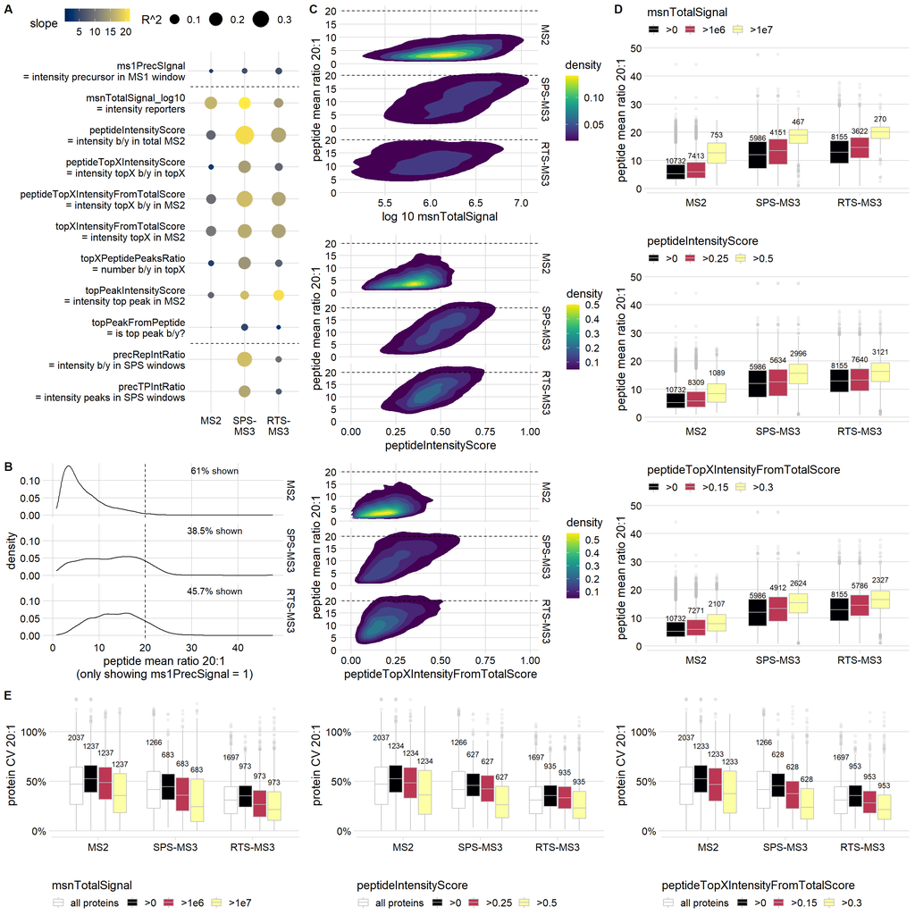

```r
# ##Fig 4: HYpro16 MS2/3 filter options (IQ vs FP / MQ) - wide version
# p_fig4b <- plot_grid(p_ratio_cor_msnTotalSignal_log10, p_pep_ratio_msnTotalSignal_log10,
#                      p_min2_CV_msnTotalSignal,
#                      p_ratio_cor_peptideIntensityScore, p_pep_ratio_peptideIntensityScore,
#                      p_min2_CV_peptideIntensityScore,
#                      p_ratio_cor_peptideTopXIntensityFromTotalScore, p_pep_ratio_peptideTopXIntensityFromTotalScore,
#                      p_min2_CV_peptideTopXIntensityFromTotalScore,
#                      labels = LETTERS[3:5], ncol = 3, align = "v", axis = "lr")
# p_fig4a <- plot_grid(p_point_slope + theme(legend.position = "none"), p_point_slope_legend, p_ratio_density_ms1PrecSIgnal_1, labels = c("A", "", "B"), rel_heights = c(1.9, 0.1, 1), ncol = 1)
# plot_grid(p_fig4a, p_fig4b, rel_widths = c(1, 3))
# ggsave2("figures/fig_4.pdf", width = 20, height = 10)

##Fig 4: HYpro16 MS2/3 filter options (IQ vs FP / MQ)
p_fig4b <- plot_grid(p_ratio_cor_msnTotalSignal_log10, p_pep_ratio_msnTotalSignal_log10,
                     p_ratio_cor_peptideIntensityScore, p_pep_ratio_peptideIntensityScore,
                     p_ratio_cor_peptideTopXIntensityFromTotalScore, p_pep_ratio_peptideTopXIntensityFromTotalScore,
                     labels = c("C", "D"), ncol = 2)
p_fig4l <- plot_grid(NULL, p_point_slope_legend, nrow = 1, rel_widths = c(0.1, 0.9))
p_fig4a <- plot_grid(p_fig4l, p_point_slope + theme(legend.position = "none"), p_ratio_density_ms1PrecSIgnal_1,
                     labels = c("A", "", "B"), rel_heights = c(0.2, 1.8, 1), ncol = 1)
p_fig4ab <- plot_grid(p_fig4a, p_fig4b, rel_widths = c(1, 2))
p_fig4c <- plot_grid(p_min2_CV_msnTotalSignal, p_min2_CV_peptideIntensityScore, p_min2_CV_peptideTopXIntensityFromTotalScore,
                     nrow = 1, labels = c("E"), align = "h", axis = "tb")
plot_grid(p_fig4ab, p_fig4c, rel_heights = c(3, 1), nrow = 2)
```

```r
ggsave2("figures/fig_4.pdf", width = 15, height = 15)
```

### Figure S7

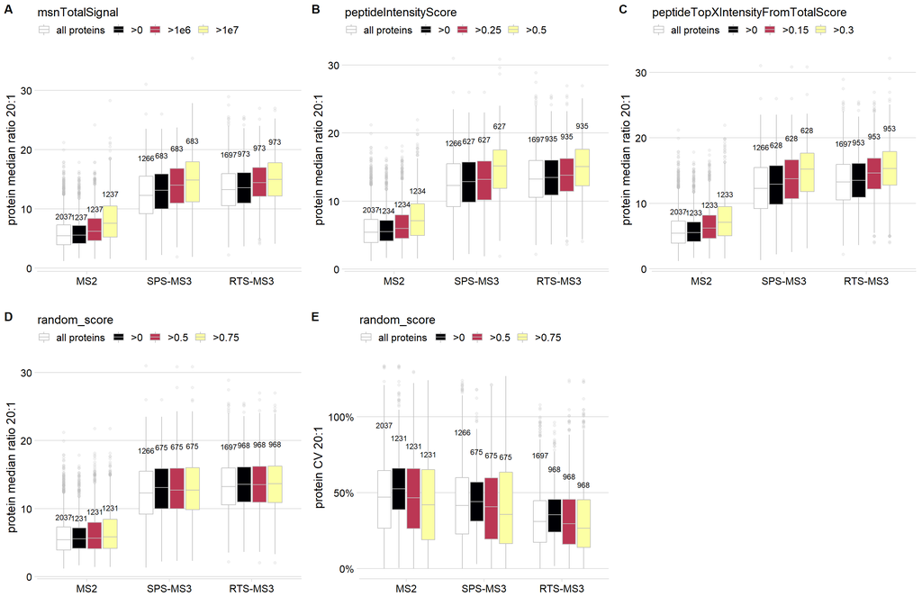

```r
#protein-level accuracy and randomized score control
plot_grid(p_min2_ratio_msnTotalSignal, p_min2_ratio_peptideIntensityScore, p_min2_ratio_peptideTopXIntensityFromTotalScore,
                        p_min2_ratio_random_score, p_min2_CV_random_score,
                        labels = LETTERS[1:5], ncol = 3)
```

```r
ggsave2("figures/fig_S7.pdf", width = 15, height = 10)
```

# Read FragPipe wide format

FragPipe psm.tsv files are read and arranged in wide format.

```r
#load tsv report files
data_FP <- rbind(fread("data/FragPipe_psm_MS3.tsv"), fread("data/FragPipe_psm_MS2.tsv"))
sample_dil_val0 <- c("empty-01", string_combine(list( c("1to20", "1to10", "1to4", "1to2", "1to1"), paste0(0L, 1:3L) ), "-"))

#keep wide data table
data_FPw <- copy(data_FP)
setnames(data_FPw, sample_dil_val0, sample_dil_val)

data_FPw[, sample := factor(gsub("^[^_]*_([^_]*_.).*$", "\\1", Spectrum), levels = cond_val)]
data_FPw[, condition := factor(gsub("^(.*)_.$", "\\1", sample), levels = cond_met_val_old, labels = cond_met_val)]
data_FPw[, replicate := factor(gsub("^.*_(.)$", "\\1", sample), levels = 1L:3L)]
data_FPw[, raw := gsub("^([^\\.]*)\\..*$", "\\1", Spectrum)]
data_FPw[, raw_file := factor(raw, levels = unique(sort(raw)), labels = 1:length(unique(raw)))]

data_FPw[, reverse := F]
data_FPw[, gene := Gene]
data_FPw[, protein := gsub("^[^\\|]*\\|([^\\|]*)\\|[^\\|]*$", "\\1", Protein)]
data_FPw[`Mapped Proteins`=="", protein_merged := Protein]
data_FPw[`Mapped Proteins`!="", protein_merged := paste0(Protein, ", ", `Mapped Proteins`)]
data_FPw[, protein_split := sapply(protein_merged, function(x) strsplit(x, ", ", fixed=T) )]
data_FPw[, proteins := lapply(protein_split, function(x) gsub("^[^\\|]*\\|([^\\|]*)\\|[^\\|]*$", "\\1", x) )]
data_FPw[, organism := sapply(protein_split, function(x) dcast_unique_sort(gsub("^[^\\|]*\\|[^\\|]*\\|[^\\|]*_(.*)$", "\\1", x)) )]
data_FPw[!organism %in% c("HUMAN", "YEAST", "HUMAN;YEAST"), organism := "OTHER"]
data_FPw[, peptide_mod := peptide_gsub(`Modified Peptide`, input = "FP")]
data_FPw[`Modified Peptide`=="", peptide_mod := Peptide]
data_FPw[, peptide_seq := Peptide]
data_FPw[, peptide_z := paste0(peptide_mod, "_", Charge)]
data_FPw[, charge := Charge]
data_FPw[, mz_ratio := `Observed M/Z`]
data_FPw[, intensity_MS1 := Intensity]
data_FPw[, score := Hyperscore]
data_FPw[, qscore := Purity]
data_FPw[, scan_ms2 := as.integer(gsub("^[^_]*_[^_]*_.\\.([^\\.]*)\\..*$", "\\1", Spectrum))]

data_FPw <- data_FPw[, .SD, .SDcols = c("raw", "sample", "condition", "replicate", "raw_file", "reverse",
                                        "gene", "protein", "proteins", "organism", "peptide_mod", "peptide_seq", "peptide_z",
                                        "charge", "mz_ratio", sample_dil_val, "intensity_MS1", "score", "qscore", "scan_ms2")]
setkey(data_FPw, sample, peptide_z)

#check intensity for validity, and set 0 to NA
for (j in which(names(data_FPw) %in% sample_dil_val))
  set(data_FPw,which(data_FPw[[j]]==0),j,NA)
#log10 transform intensity,
data_FPw[, (sample_dil_val) := log10(.SD), .SDcols = sample_dil_val]

data_FPw <- copy(data_FPw)
setkey(data_FPw, sample, peptide_z)
```

# Read FragPipe long format

FragPipe psm.tsv files are arranged in tidy format.

```r
#for tidy table: melt
data_FP <- melt(data_FP, measure.vars = sample_dil_val0, variable.name = "sample", value.name = "intensity")

#parse columns and create conditions
data_FP[, sample_met := factor(gsub("^[^_]*_([^_]*_.).*$", "\\1", Spectrum), levels = cond_val)]
data_FP[, sample_dil := factor(sample, levels = sample_dil_val0, labels = sample_dil_val)]
data_FP[, sample := factor(paste0(sample_met, "_", sample_dil), levels = sample_val)]
data_FP[, condition := factor(gsub("^(.*_.*)_.*_.$", "\\1", sample), levels = cond_val)]
data_FP[, cond_met := factor(gsub("^(.*)_.*_.*_.$", "\\1", sample), levels = cond_met_val_old, labels = cond_met_val)]
data_FP[, cond_dil := factor(gsub("^.*_._(.*_.)$", "\\1", sample), levels = sample_dil_val)]
data_FP[, replicate := factor(gsub("^.*_(.)$", "\\1", sample), levels = 1L:3L)]
data_FP[, rep_met := factor(gsub("^.*_(.)_.*_.$", "\\1", sample), levels = 1L:3L)]
data_FP[, raw := gsub("^([^\\.]*)\\..*$", "\\1", Spectrum)]
data_FP[, raw_file := factor(raw, levels = unique(sort(raw)), labels = 1:length(unique(raw)))]
data_FP[, reverse := F]
data_FP[, gene := Gene]
data_FP[, protein := gsub("^[^\\|]*\\|([^\\|]*)\\|[^\\|]*$", "\\1", Protein)]
data_FP[`Mapped Proteins`=="", protein_merged := Protein]
data_FP[`Mapped Proteins`!="", protein_merged := paste0(Protein, ", ", `Mapped Proteins`)]
data_FP[, protein_split := sapply(protein_merged, function(x) strsplit(x, ", ", fixed=T) )]
data_FP[, proteins := lapply(protein_split, function(x) gsub("^[^\\|]*\\|([^\\|]*)\\|[^\\|]*$", "\\1", x) )]
data_FP[, organism := sapply(protein_split, function(x) dcast_unique_sort(gsub("^[^\\|]*\\|[^\\|]*\\|[^\\|]*_(.*)$", "\\1", x)) )]
data_FP[!organism %in% c("HUMAN", "YEAST", "HUMAN;YEAST"), organism := "OTHER"]
data_FP[, peptide_mod := peptide_gsub(`Modified Peptide`, input = "FP")]
data_FP[`Modified Peptide`=="", peptide_mod := Peptide]
data_FP[, peptide_seq := Peptide]
data_FP[, peptide_z := paste0(peptide_mod, "_", Charge)]
data_FP[, charge := Charge]
data_FP[, mz_ratio := `Observed M/Z`]
data_FP[, intensity := intensity]
data_FP[, intensity_MS1 := Intensity]
data_FP[, score := Hyperscore]
data_FP[, qscore := Purity]
data_FP[, scan_ms2 := as.integer(gsub("^[^_]*_[^_]*_.\\.([^\\.]*)\\..*$", "\\1", Spectrum))]

data_FP <- data_FP[, .(sample, condition, cond_met, cond_dil, replicate, rep_met, raw_file, reverse,
                 gene, protein, proteins, organism, peptide_mod, peptide_seq, peptide_z,
                 charge, mz_ratio, intensity, intensity_MS1, score, qscore, scan_ms2)]

#check intensity for validity, and set 0 to NA
data_FP[, check_nonval(intensity)]
```

```
## [1] "Total of 1727888 contains 557244 0s, 0 1s, 0 inf, 0 NA 0 NAN and 1170644 valid"
```

[output not shown]

```r
data_FP[intensity==0 | intensity==1, intensity := NA]
#log10 transform intensity,
data_FP[, intensity := log10(intensity)]

data_FP <- copy(data_FP)
setkey(data_FP, sample, peptide_z)
```

# Read MaxQuant msms.txt

MaxQuant v2.0.3.1 at the time of submission had a bug in processing MS3-level TMTpro data, which is being fixed in an upcoming release. But for this script, MS3-level quant data is provided, but excluded due to vastly inaccurate quantification.

```r
#load msms
data_MQ <- rbind(fread("data/MaxQuant_msms_MS3.txt"), fread("data/MaxQuant_msms_MS2.txt"))

#need to delete all TMT reporter ion columns, because not filled for MS3-based TMTpro
data_MQ[, grep("^Reporter (intensity|mass)", names(data_MQ), value=T) := NULL]


#load msmsScans for mapping TMT reporter intensities
data_MQ_TMT <- rbind(fread("data/MaxQuant_msmsScans_MS3.txt"), fread("data/MaxQuant_msmsScans_MS2.txt"))

#map TMT reporter ion columns onto msms
tmt_old <- paste0("Reporter intensity ", 1:16 )

data_MQ <- merge(x=data_MQ, y=data_MQ_TMT[, .SD, .SDcols = c("Raw file", "Scan number", tmt_old)],
                 by = c("Raw file", "Scan number"), all.x=T, all.y=F)

#melt TMT evidence into tidy table
data_MQ <- melt(data_MQ, measure.vars = tmt_old, variable.name = "sample", value.name = "intensity")

#parse columns and create conditions
data_MQ[, sample_met := factor(gsub("^[^_]*_([^_]*_.)*$", "\\1", `Raw file`), levels = cond_val)]
data_MQ[, cond_dil := factor(sample, levels = tmt_old, labels = sample_dil_val)]
data_MQ[, sample := factor(paste0(sample_met, "_", cond_dil), levels = sample_val)]
data_MQ[, condition := factor(gsub("^(.*_.*)_.*_.$", "\\1", sample), levels = cond_val)]
data_MQ[, cond_met := factor(gsub("^(.*)_.*_.*_.$", "\\1", sample), levels = cond_met_val_old, labels = cond_met_val)]
data_MQ[, replicate := factor(gsub("^.*_(.)$", "\\1", sample), levels = 1L:3L)]
data_MQ[, rep_met := factor(gsub("^.*_(.)_.*_.$", "\\1", sample), levels = 1L:3L)]
data_MQ[, raw_file := factor(`Raw file`, levels = unique(sort(`Raw file`)), labels = 1:length(unique(`Raw file`)))]

data_MQ[, reverse := Reverse]
data_MQ[, gene := character()]
data_MQ[, proteins := Proteins]
data_MQ[, protein := gsub("^([^;]*);.*$", "\\1", Proteins)]

data_MQ[, peptide_mod := peptide_gsub(gsub("^_(.*)_$", "\\1", `Modified sequence`), "MQ")]
data_MQ[, peptide_seq := Sequence]
data_MQ[, peptide_z := paste0(peptide_mod, "_", Charge)]
data_MQ[, charge := Charge]
data_MQ[, mz_ratio := `m/z`]
data_MQ[, intensity_MS1 := numeric()]
data_MQ[, score := Score]
data_MQ[, qscore := PIF]
data_MQ[, scan_ms2 := `Scan number`]
data_MQ <- data_MQ[, .(sample, sample_met, condition, cond_met, cond_dil, replicate, rep_met, raw_file, reverse,
                 gene, protein, proteins, peptide_mod, peptide_seq, peptide_z,
                 charge, mz_ratio, intensity, intensity_MS1,
                 score, qscore, scan_ms2)]
setkey(data_MQ, sample, peptide_z)

#map organism onto data
org <- fread("data/yeast_human_organism_mapping.csv")
org[organism=="yeast", organism := "YEAST"]
org[organism=="human", organism := "HUMAN"]
data_MQ <- merge(data_MQ, org, by = "protein", all.x=T, all.y=F)
data_MQ[is.na(organism), organism := "OTHER"]

#filter reverse hits
data_MQ <- data_MQ[!reverse=="+"]

#check intensity for validity, and set 0 to NA
data_MQ[, check_nonval(intensity)]
```

```
## [1] "Total of 1257088 contains 28163 0s, 0 1s, 0 inf, 432624 NA 0 NAN and 796301 valid"
```

[output not shown]

```r
data_MQ[intensity==0 | intensity==1, intensity := NA]
#log10 transform intensity,
data_MQ[, intensity := log10(intensity)]

data_MQ <- copy(data_MQ)
setkey(data_MQ, sample, peptide_z)
```

# Software comparison

The Comet-Mokapot-IsobaricQuant pipeline is compared with FragPipe (MS2- and MS3-readout) as well as MaxQuant (MS2-readout).

## Number of quantifications

```r
#Goal: how many quantified spectra per sample with any number of TMT reporter ions?
count_spectra_CO <- data_CO[!is.na(intensity), .N, keyby = c("condition", "cond_met", "scan_ms2")
                            ][, .(type="IQ", .N), keyby = c("condition", "cond_met")]
count_spectra_FP <- data_FP[!is.na(intensity), .N, keyby = c("condition", "cond_met", "scan_ms2")
                            ][, .(type="FP", .N), keyby = c("condition", "cond_met")]
count_spectra_MQ <- data_MQ[!is.na(intensity), .N, keyby = c("condition", "cond_met", "scan_ms2")
                            ][, .(type="MQ", .N), keyby = c("condition", "cond_met")]
count_spectra <- rbind(count_spectra_CO, count_spectra_FP, count_spectra_MQ[cond_met %in% "MS2"])
count_spectra[, type := factor(type, levels = cond_qua_val)]
count_spectra[, cond_met := factor(cond_met, levels = cond_met_val)]

p_nr_quants <- ggplot(count_spectra, aes(x=cond_met, y=N, fill=type)) +
  geom_bar(stat="summary", fun="mean", position="dodge", alpha=0.5) +
  geom_point(position = position_dodge(width = 0.9), shape=1L) +
  scale_fill_manual("", values = cond_qua_col) +
  xlab("") + ylab("quantified scan groups") +
  theme_minimal_hgrid()


#Goal: distribution of % TMT reporters per spectra? separated by organism
count_nr_TMT <-
  rbind(data_FP[!is.na(intensity) & organism!="OTHER", .N, keyby = c("condition", "cond_met", "organism", "scan_ms2")][, .(type="FP", quant_rel = .SD[N==16, .N]/.N), keyby = c("condition", "cond_met", "organism")],
        data_CO[!is.na(intensity) & organism!="OTHER", .N, keyby = c("condition", "cond_met", "organism", "scan_ms2")][, .(type="IQ", quant_rel = .SD[N==16, .N]/.N), keyby = c("condition", "cond_met", "organism")],
        data_MQ[!is.na(intensity) & organism!="OTHER" & cond_met %in% "MS2", .N, keyby = c("condition", "cond_met", "organism", "scan_ms2")][, .(type="MQ", quant_rel = .SD[N==16, .N]/.N), keyby = c("condition", "cond_met", "organism")])
count_nr_TMT[, type := factor(type, levels = cond_qua_val)]
count_nr_TMT[, cond_met := factor(cond_met, levels = cond_met_val)]

p_frc_full_quant <- ggplot(count_nr_TMT, aes(x=cond_met, y=quant_rel, fill=type)) +
  geom_bar(stat="summary", fun="mean", position="dodge", alpha=0.5) +
  geom_point(position = position_dodge(width = 0.9), shape=1L) +
  scale_fill_manual("", values = cond_qua_col) +
  xlab("") + ylab("scan groups with\nfull 16plex quantification") +
  facet_grid(cols = vars(organism)) +
  theme_minimal_hgrid() + theme_yaxis_percentage


#Goal: distribution of % TMT reporters per channel? separated by organism
count_nr_channel <-
  rbind(data_FP[!is.na(intensity) & organism!="OTHER", .(.N, type = "FP"), keyby = c("condition", "cond_met", "organism", "cond_dil")],
        data_CO[!is.na(intensity) & organism!="OTHER", .(.N, type = "IQ"), keyby = c("condition", "cond_met", "organism", "cond_dil")],
        data_MQ[!is.na(intensity) & organism!="OTHER" & cond_met %in% "MS2", .(.N, type = "MQ"), keyby = c("condition", "cond_met", "organism", "cond_dil")])
count_nr_channel[, type := factor(type, levels = cond_qua_val)]
count_nr_channel[, cond_met := factor(cond_met, levels = cond_met_val)]
count_nr_channel[, cond_dil := factor(cond_dil, levels = sample_dil_val)]

p_frc_channel_quant <- ggplot(count_nr_channel[organism=="YEAST"], aes(x=cond_dil, y=N, fill=type)) +
  geom_bar(stat="summary", fun="mean", position="dodge", alpha=0.5) +
  geom_point(position = position_dodge(width = 0.9), shape=1L) +
  scale_fill_manual("", values = cond_qua_col) +
  xlab("") + ylab("number of quantified channels\nper yeast scan group") +
  facet_grid(cols = vars(cond_met)) + theme_minimal_hgrid() + theme_tilt_xaxis(90, T)




#Goal: distribution of % TMT reporters per spectra? YEAST both only
data_yeast_scans <- rbind(data_CO[organism=="YEAST", .(type="IQ", sample, cond_met, scan_ms2)],
                          data_FP[organism=="YEAST", .(type="FP", sample, cond_met, scan_ms2)],
                          data_MQ[organism=="YEAST" & cond_met %in% "MS2", .(type="MQ", sample, cond_met, scan_ms2)])

data_yeast_scans <- rbind(data_yeast_scans[cond_met %in% c("MS2"), .N, by = c("sample", "scan_ms2")][N==3, .(sample, scan_ms2, yeast=T)],
                          data_yeast_scans[cond_met %in% cond_met_val[2:3], .N, by = c("sample", "scan_ms2")][N==2, .(sample, scan_ms2, yeast=T)])
setkey(data_yeast_scans, sample, scan_ms2)

data_FPy <- merge(x=data_FP, y=data_yeast_scans, by=c("sample", "scan_ms2"))
data_COy <- merge(x=data_CO, y=data_yeast_scans, by=c("sample", "scan_ms2"))
data_MQy <- merge(x=data_MQ[cond_met %in% "MS2"], y=data_yeast_scans, by=c("sample", "scan_ms2"))

count_nr_TMTy <-
  rbind(data_FPy[!is.na(intensity), .N, keyby = c("condition", "cond_met", "scan_ms2")][, .(type="FP", quant_rel = .SD[N==16, .N]/.N), keyby = c("condition", "cond_met")],
        data_COy[!is.na(intensity), .N, keyby = c("condition", "cond_met", "scan_ms2")][, .(type="IQ", quant_rel = .SD[N==16, .N]/.N), keyby = c("condition", "cond_met")],
        data_MQy[!is.na(intensity), .N, keyby = c("condition", "cond_met", "scan_ms2")][, .(type="MQ", quant_rel = .SD[N==16, .N]/.N), keyby = c("condition", "cond_met")])
count_nr_TMTy[, type := factor(type, levels = cond_qua_val)]
count_nr_TMTy[, cond_met := factor(cond_met, levels = cond_met_val)]

p_frc_full_quant_yeast <- ggplot(count_nr_TMTy, aes(x=cond_met, y=quant_rel, fill=type)) +
  geom_bar(stat="summary", fun="mean", position="dodge", alpha=0.5) +
  geom_point(position = position_dodge(width = 0.9), shape=1L) +
  scale_fill_manual("", values = cond_qua_col) +
  xlab("") + ylab("\nshared yeast scan groups\nwith full 16plex quantification") +
  theme_minimal_hgrid() + theme_yaxis_percentage
```

### Figure S2

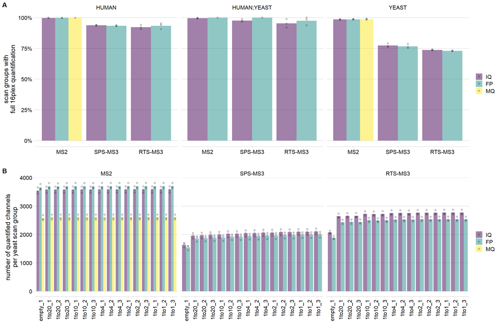

```r
#number of quantified scan groups with full 16plex
#number of quantified yeast channels
plot_grid(p_frc_full_quant, p_frc_channel_quant, labels = "AUTO", ncol = 1, align = "v", axis = "lr")
```

```r
ggsave2("figures/fig_S2.pdf", width = 15, height = 10)
```

## Quant correlation

```r
#Goal: quant correlation
#merge datasets
data_IQFP <- merge(x=data_CO[, .(sample, condition, cond_dil, scan_ms2, intensity)],
                   y=data_FP[, .(sample, condition, cond_dil, scan_ms2, intensity)],
                   by = c("sample", "condition", "cond_dil", "scan_ms2"))
setnames(data_IQFP, c("intensity.x", "intensity.y"), c("int_IQ", "int_FP"))
data_IQFP <- data_IQFP[!(is.na(int_IQ) & is.na(int_FP))]

#calculate correlations
lab_IQFP <- data_IQFP[!is.na(int_IQ) & !is.na(int_FP), .(pearson = round(cor(int_IQ, int_FP)^2, 6)), keyby = c("condition")]
cor_IQPF <- data_IQFP[!is.na(int_IQ) & !is.na(int_FP), round(cor(int_IQ, int_FP)^2, 6)]

p_IQ_FP_correlation_cond <- ggplot(data_IQFP, aes(x=int_IQ, y=int_FP)) +
  stat_binhex(aes(fill=log10(..count..))) + geom_abline() +
  geom_text(data=lab_IQFP, aes(x=2.2, y=7.5, label=paste0("R^2 = ", pearson)), hjust=0) +
  facet_wrap(vars(condition)) + xlab("IQ log10 intensity") + ylab("FP log10 intensity") +
  scale_fill_viridis("log10\ncounts") +
  theme_minimal_grid()

p_IQ_FP_correlation <- ggplot(data_IQFP, aes(x=int_IQ, y=int_FP)) +
  stat_binhex(aes(fill=log10(..count..))) + geom_abline() +
  annotate("text", x=2.2, y=7.5, label=paste0("R^2 = ", cor_IQPF), hjust=0) +
  xlab("IQ log10 intensity") + ylab("FP log10 intensity") +
  scale_fill_viridis("log10\ncounts") +
  theme_minimal_grid()



#merge datasets
data_IQMQ <- merge(x=data_CO[cond_met %in% "MS2", .(sample, condition, cond_dil, scan_ms2, intensity)],
                   y=data_MQ[cond_met %in% "MS2", .(sample, condition, cond_dil, scan_ms2, intensity)],
                   by = c("sample", "condition", "cond_dil", "scan_ms2"))
setnames(data_IQMQ, c("intensity.x", "intensity.y"), c("int_IQ", "int_MQ"))
data_IQMQ <- data_IQMQ[!(is.na(int_IQ) & is.na(int_MQ))]

#calculate correlations
lab_IQMQ <- data_IQMQ[!is.na(int_IQ) & !is.na(int_MQ), .(pearson = round(cor(int_IQ, int_MQ)^2, 6)), keyby = c("condition")]
cor_IQMQ <- data_IQMQ[!is.na(int_IQ) & !is.na(int_MQ), round(cor(int_IQ, int_MQ)^2, 6)]

p_IQ_MQ_correlation_cond <- ggplot(data_IQMQ, aes(x=int_IQ, y=int_MQ)) +
  stat_binhex(aes(fill=log10(..count..))) + geom_abline() +
  geom_text(data=lab_IQMQ, aes(x=2.2, y=7.5, label=paste0("R^2 = ", pearson)), hjust=0) +
  facet_wrap(vars(condition)) + xlab("IQ log10 intensity") + ylab("MQ log10 intensity") +
  scale_fill_viridis("log10\ncounts") +
  theme_minimal_grid()

p_IQ_MQ_correlation <- ggplot(data_IQMQ, aes(x=int_IQ, y=int_MQ)) +
  stat_binhex(aes(fill=log10(..count..))) + geom_abline() +
  annotate("text", x=2.2, y=7.5, label=paste0("R^2 = ", cor_IQMQ), hjust=0) +
  xlab("IQ log10 intensity") + ylab("MQ log10 intensity") +
  scale_fill_viridis("log10\ncounts") +
  theme_minimal_grid()
```

### Figure 2

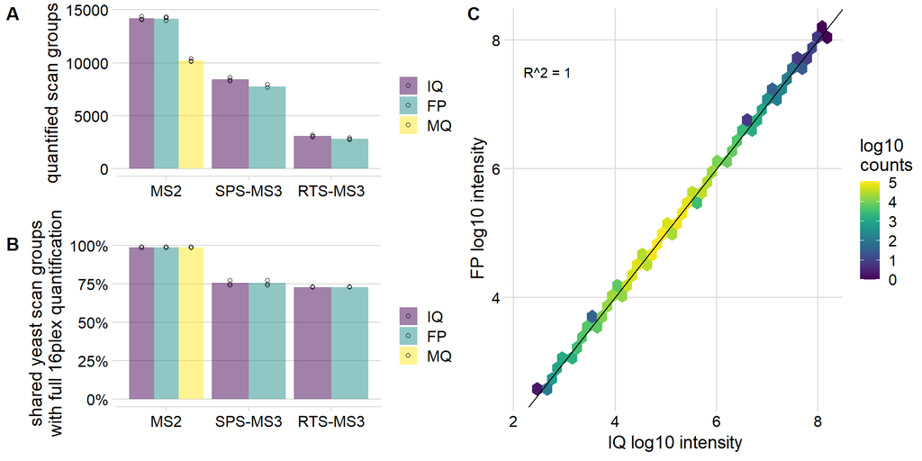

```r
#number of quantified scan groups
#yeast fraction of quants with full 16plex quantification
#direct correlation of all quants (IQ vs FP)
p_fig2a <- plot_grid(p_nr_quants, p_frc_full_quant_yeast, ncol = 1, labels = "AUTO", align = "v", axis = "lr")
plot_grid(p_fig2a, p_IQ_FP_correlation, nrow = 1, labels = c("", "C"))
```

```r
ggsave2("figures/fig_2.pdf", width = 10, height = 5)
```

##Quant matches

```r
#Goal: bar plot showing fraction of hits matched
data_IQFP <- merge(x=data_CO[, .(sample, condition, cond_met, cond_dil, scan_ms2, intensity)],
                   y=data_FP[, .(sample, condition, cond_met, cond_dil, scan_ms2, intensity)],
                   by = c("sample", "condition", "cond_met", "cond_dil", "scan_ms2"))
setnames(data_IQFP, c("intensity.x", "intensity.y"), c("int_IQ", "int_FP"))
data_IQFP <- data_IQFP[!is.na(int_IQ) & !is.na(int_FP)]

data_IQFP[, int_match := round(int_IQ, 2)==round(int_FP, 2)]
count_IQFP <- data_IQFP[, .(int_match = .SD[int_match==T, .N]/.N, type = "IQ vs FP"), keyby = c("condition", "cond_met")]

data_IQMQ <- merge(x=data_CO[, .(sample, condition, cond_met, cond_dil, scan_ms2, intensity)],
                   y=data_MQ[cond_met %in% "MS2", .(sample, condition, cond_met, cond_dil, scan_ms2, intensity)],
                   by = c("sample", "condition", "cond_met", "cond_dil", "scan_ms2"))
setnames(data_IQMQ, c("intensity.x", "intensity.y"), c("int_IQ", "int_MQ"))
data_IQMQ <- data_IQMQ[!is.na(int_IQ) & !is.na(int_MQ)]

data_IQMQ[, int_match := round(int_IQ, 2)==round(int_MQ, 2)]
count_IQMQ <- data_IQMQ[, .(int_match = .SD[int_match==T, .N]/.N, type = "IQ vs MQ"), keyby = c("condition", "cond_met")]

p_quant_match <- ggplot(rbind(count_IQFP, count_IQMQ), aes(x=cond_met, y=int_match, fill=type)) +
  geom_bar(stat="summary", fun="mean", position="dodge", alpha=0.5) +
  geom_point(position = position_dodge(width = 0.9), shape=1L) +
  scale_fill_viridis_d("") + theme_yaxis_percentage +
  xlab("") + ylab("intensities matching 2 digits") +
  theme_minimal_hgrid()


#Goal: bar plot showing fraction of hits matched per reporter channel
count_IQFP_rep <- data_IQFP[, .(int_match = .SD[int_match==T, .N]/.N, type = "IQ vs FP"), keyby = c("condition", "cond_met", "cond_dil")]
count_IQMQ_rep <- data_IQMQ[, .(int_match = .SD[int_match==T, .N]/.N, type = "IQ vs MQ"), keyby = c("condition", "cond_met", "cond_dil")]

p_quant_match_rep <- ggplot(rbind(count_IQFP_rep, count_IQMQ_rep), aes(x=cond_dil, y=int_match, fill=type)) +
  geom_bar(stat="summary", fun="mean", position="dodge", alpha=0.5) +
  geom_point(position = position_dodge(width = 0.9), shape=1L) +
  scale_fill_viridis_d("") + theme_yaxis_percentage +
  facet_grid(cols = vars(cond_met)) +
  xlab("") + ylab("intensities\nmatching 2 digits") +
  theme_minimal_hgrid() + theme_tilt_xaxis(90, T)
```

### Figure S3

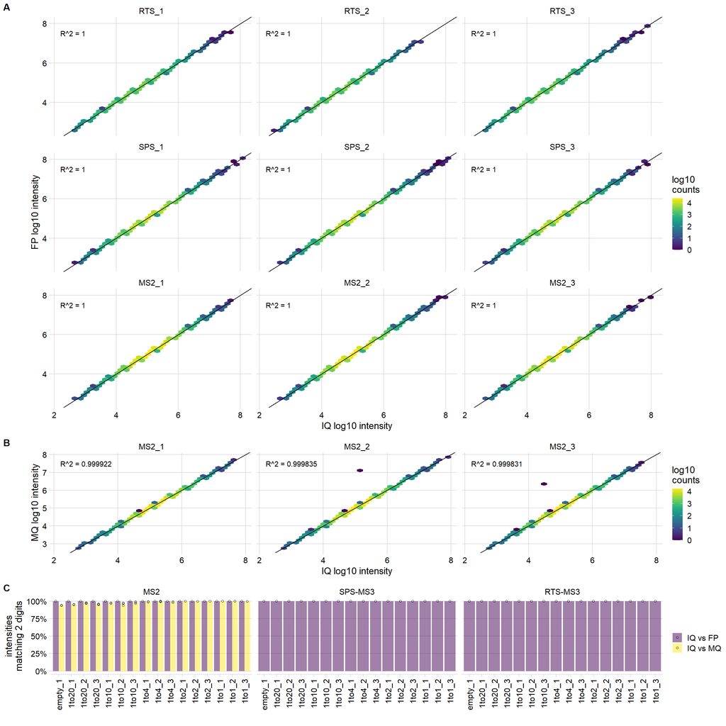

```r
#all fractions of quants with full 16plex quantification
#all quant correlations FP & MS2 quant correlations MQ
#share of matching quants
plot_grid(p_IQ_FP_correlation_cond, p_IQ_MQ_correlation_cond, p_quant_match_rep,
          ncol = 1, labels = "AUTO", rel_heights = c(3,1,1), align = "v", axis = "lr")
```

```r
ggsave2("figures/fig_S3.pdf", width = 15, height = 15)
```

## QC correllations

```r
#Goal: see correlation of IQ ms1PrecSIgnal vs FP purity
#merge IQ and FP wide datasets
data_IQFPw <- merge(x=data_COw[, .(sample, condition, scan_ms2, ms1PrecSIgnal, ratio_20_m)],
                    y=data_FPw[, .(sample, condition, scan_ms2, qscore)],
                    by = c("sample", "condition", "scan_ms2"))
setnames(data_IQFPw, c("qscore"), c("purity"))
data_IQFPw <- data_IQFPw[!(is.na(ms1PrecSIgnal) & is.na(purity))]

p_ms1PrecSignal_vs_purity_cor <- ggplot(data_IQFPw[ms1PrecSIgnal!=1 & purity!=1], aes(x=ms1PrecSIgnal, y=purity)) +
  stat_density_2d(geom = "polygon", aes(fill = after_stat(level))) + geom_abline(linetype="dashed") + facet_grid(cols = vars(condition)) +
  scale_fill_viridis("density") + xlim(0.5,1.1) + ylim(0.6,1.05) +
  xlab("IQ ms1PrecSIgnal (excluding =1)") + ylab("FQ purity (excluding =1)") + theme_minimal_grid()



#Goal: how many scans have both parameters = 1
data_IQFPw[, ms1PrecSIgnal_1 := ifelse(ms1PrecSIgnal==1, T, F)]
data_IQFPw[, purity_1 := ifelse(purity==1, T, F)]

count_QC_par_1 <- data_IQFPw[, .N, keyby = c("condition", "ms1PrecSIgnal_1", "purity_1")]
count_QC_par_1[, cond := paste0(as.integer(ms1PrecSIgnal_1), "_", as.integer(purity_1))]

p_main <- ggplot(count_QC_par_1, aes(x=cond, y=N)) +
  geom_bar(stat="identity") + xlab("") + ylab("ms2 scans") + facet_grid(cols = vars(condition)) +
  theme_minimal_hgrid() + theme(axis.text.x=element_blank())

upset_col <- c("ms1PrecSIgnal = 1", "purity = 1")
count_QC_par_1[, (upset_col) := tstrsplit(cond, "_")]
upset_dt <- melt(count_QC_par_1, measure.vars = upset_col)

p_sub <- ggplot(upset_dt, aes(x=cond, y=variable, alpha=value)) +
  geom_point(size=4) + facet_grid(cols = vars(condition)) +
  scale_alpha_manual("ms1PrecSIgnal = 1", values = c("1" = 1, "0" = 0.1)) +
  theme_void() + theme(legend.position = "none", axis.text.y = element_text(hjust=1), strip.text.x = element_blank())

p_ms1PrecSignal_vs_purity_bar <- plot_grid(p_main, p_sub, nrow = 2, rel_heights = c(0.9, 0.1), align = "v", axis = "lr")
```

### Figure S6

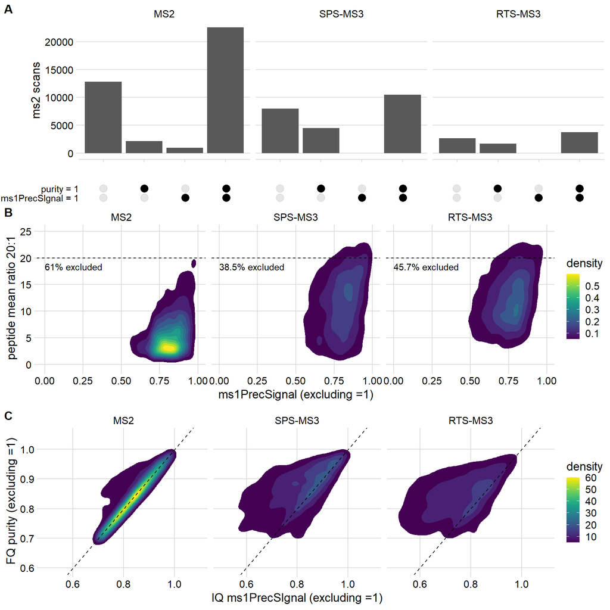

```r
#correlation of IQ ms1PrecSignal vs FP purity
plot_grid(p_ms1PrecSignal_vs_purity_bar, p_ratio_cor_ms1PrecSIgnal, p_ms1PrecSignal_vs_purity_cor, labels = "AUTO", ncol = 1)
```

```r
ggsave2("figures/fig_S6.pdf", width = 10, height = 10)
```